# FINAL_PROJECT

## **Machine Learning Project for CDAC**

### **Working with Lending_Club_Dataset**

## Submitted by:

#### Aditya Nagose: 220940141001

#### Anjali Sangode : 220940141005

#### Pooja Jadhav : 220940141017

#### Taksande Sandeep Ravindra : 220940141028

## **1. Introduction**

LendingClub is a US peer-to-peer lending company, headquartered in San Francisco, California. It was the first peer-to-peer lender to register its offerings as securities with the Securities and Exchange Commission (SEC), and to offer loan trading on a secondary market. LendingClub is the world's largest peer-to-peer lending platform.

Solving this case study will provide an idea about how real business problems are solved using EDA and Machine Learning. In this case study, we will also develop a basic understanding of risk analytics in banking and financial services and understand how data is used to minimise the risk of losing money while lending to customers.

### The Dataset contains all entries from year 2007 to 2018

## **2. Mounting the Google Drive and setting up the work environment**

import time prog_start = time.time()

from google.colab import drive drive.mount('/content/gdrive')

!ls

## **3. Installing and loading the essential libraries**

```python
import numpy as np
import pandas as pd
import seaborn as sns
import matplotlib.pyplot as plt
from matplotlib import rcParams
from scipy import stats
import warnings
from sklearn import datasets
from sklearn import linear_model
from sklearn.metrics import explained_variance_score
from sklearn.linear_model import LogisticRegression
from sklearn.ensemble import RandomForestClassifier
from sklearn.tree import DecisionTreeClassifier, DecisionTreeRegressor
from sklearn.naive_bayes import GaussianNB
from xgboost import XGBClassifier
from sklearn.datasets import make_classification
from sklearn.model_selection import RepeatedStratifiedKFold
from lightgbm import LGBMClassifier
from catboost import CatBoostClassifier
from sklearn.neighbors import KNeighborsClassifier
from sklearn.svm import SVC
from sklearn.model_selection import cross_val_score
from sklearn.metrics import classification_report, confusion_matrix, ConfusionMatrixDisplay
from sklearn.metrics import plot_confusion_matrix, plot_roc_curve, roc_auc_score
from sklearn.model_selection import GridSearchCV
from sklearn.model_selection import RandomizedSearchCV
from sklearn.experimental import enable_iterative_imputer
from sklearn.impute import IterativeImputer
from sklearn.linear_model import LinearRegression
from sklearn.preprocessing import StandardScaler
from sklearn.preprocessing import normalize
from sklearn.model_selection import train_test_split
from sklearn.preprocessing import LabelEncoder
from sklearn.datasets import make_blobs
from sklearn import metrics
from math import sqrt
import time


sns.set_style('darkgrid')
warnings.filterwarnings('ignore')
```

## **4. Reading the dataset**

```python
prog_start = time.time()


# time taken to read data
s_time_chunk = time.time()
df = pd.read_csv(r'D:\LendingClub\accepted.csv',low_memory=False)
e_time_chunk = time.time()

print("\n\nWithout chunks: ", (e_time_chunk-s_time_chunk)/60, " Minutes\n\n")
df.head()
```

```
Without chunks:  1.1944259643554687  Minutes
```

|  | id | member_id | loan_amnt | funded_amnt | funded_amnt_inv | term | int_rate | installment | grade | sub_grade | ... | hardship_payoff_balance_amount | hardship_last_payment_amount | disbursement_method | debt_settlement_flag | debt_settlement_flag_date | settlement_status | settlement_date | settlement_amount | settlement_percentage | settlement_term |
| --- | --- | --- | --- | --- | --- | --- | --- | --- | --- | --- | --- | --- | --- | --- | --- | --- | --- | --- | --- | --- | --- |
| 0 | 68407277 | NaN | 3600.0 | 3600.0 | 3600.0 | 36 months | 13.99 | 123.03 | C | C4 | ... | NaN | NaN | Cash | N | NaN | NaN | NaN | NaN | NaN | NaN |
| 1 | 68355089 | NaN | 24700.0 | 24700.0 | 24700.0 | 36 months | 11.99 | 820.28 | C | C1 | ... | NaN | NaN | Cash | N | NaN | NaN | NaN | NaN | NaN | NaN |
| 2 | 68341763 | NaN | 20000.0 | 20000.0 | 20000.0 | 60 months | 10.78 | 432.66 | B | B4 | ... | NaN | NaN | Cash | N | NaN | NaN | NaN | NaN | NaN | NaN |
| 3 | 66310712 | NaN | 35000.0 | 35000.0 | 35000.0 | 60 months | 14.85 | 829.90 | C | C5 | ... | NaN | NaN | Cash | N | NaN | NaN | NaN | NaN | NaN | NaN |
| 4 | 68476807 | NaN | 10400.0 | 10400.0 | 10400.0 | 60 months | 22.45 | 289.91 | F | F1 | ... | NaN | NaN | Cash | N | NaN | NaN | NaN | NaN | NaN | NaN |

5 rows × 151 columns

```python
pd.options.display.max_columns = 200
df.describe()
```

|  | member_id | loan_amnt | funded_amnt | funded_amnt_inv | int_rate | installment | annual_inc | dti | delinq_2yrs | fico_range_low | fico_range_high | inq_last_6mths | mths_since_last_delinq | mths_since_last_record | open_acc | pub_rec | revol_bal | revol_util | total_acc | out_prncp | out_prncp_inv | total_pymnt | total_pymnt_inv | total_rec_prncp | total_rec_int | total_rec_late_fee | recoveries | collection_recovery_fee | last_pymnt_amnt | … |
| --- | --- | --- | --- | --- | --- | --- | --- | --- | --- | --- | --- | --- | --- | --- | --- | --- | --- | --- | --- | --- | --- | --- | --- | --- | --- | --- | --- | --- | --- | --- |
| count | 0.0 | 2.260668e+06 | 2.260668e+06 | 2.260668e+06 | 2.260668e+06 | 2.260668e+06 | 2.260664e+06 | 2.258957e+06 | 2.260639e+06 | 2.260668e+06 | 2.260668e+06 | 2.260638e+06 | 1.102166e+06 | 359156.000000 | 2.260639e+06 | 2.260639e+06 | 2.260668e+06 | 2.258866e+06 | 2.260639e+06 | 2.260668e+06 | 2.260668e+06 | 2.260668e+06 | 2.260668e+06 | 2.260668e+06 | 2.260668e+06 | 2.260668e+06 | 2.260668e+06 | 2.260668e+06 | 2.260668e+06 | … |
| mean | NaN | 1.504693e+04 | 1.504166e+04 | 1.502344e+04 | 1.309283e+01 | 4.458068e+02 | 7.799243e+04 | 1.882420e+01 | 3.068792e-01 | 6.985882e+02 | 7.025884e+02 | 5.768354e-01 | 3.454092e+01 | 72.312842 | 1.161240e+01 | 1.975278e-01 | 1.665846e+04 | 5.033770e+01 | 2.416255e+01 | 4.206891e+03 | 4.205965e+03 | 1.208256e+04 | 1.206439e+04 | 9.505772e+03 | 2.431388e+03 | 1.518453e+00 | 1.438791e+02 | 2.398257e+01 | 3.429346e+03 | … |
| std | NaN | 9.190245e+03 | 9.188413e+03 | 9.192332e+03 | 4.832138e+00 | 2.671735e+02 | 1.126962e+05 | 1.418333e+01 | 8.672303e-01 | 3.301038e+01 | 3.301124e+01 | 8.859632e-01 | 2.190047e+01 | 26.464094 | 5.640861e+00 | 5.705150e-01 | 2.294831e+04 | 2.471307e+01 | 1.198753e+01 | 7.343239e+03 | 7.342333e+03 | 9.901383e+03 | 9.896992e+03 | 8.321852e+03 | 2.679738e+03 | 1.184159e+01 | 7.481640e+02 | 1.312256e+02 | 6.018248e+03 | … |
| min | NaN | 5.000000e+02 | 5.000000e+02 | 0.000000e+00 | 5.310000e+00 | 4.930000e+00 | 0.000000e+00 | -1.000000e+00 | 0.000000e+00 | 6.100000e+02 | 6.140000e+02 | 0.000000e+00 | 0.000000e+00 | 0.000000 | 0.000000e+00 | 0.000000e+00 | 0.000000e+00 | 0.000000e+00 | 1.000000e+00 | 0.000000e+00 | 0.000000e+00 | 0.000000e+00 | 0.000000e+00 | 0.000000e+00 | 0.000000e+00 | -9.500000e-09 | 0.000000e+00 | 0.000000e+00 | 0.000000e+00 | … |
| 25% | NaN | 8.000000e+03 | 8.000000e+03 | 8.000000e+03 | 9.490000e+00 | 2.516500e+02 | 4.600000e+04 | 1.189000e+01 | 0.000000e+00 | 6.750000e+02 | 6.790000e+02 | 0.000000e+00 | 1.600000e+01 | 55.000000 | 8.000000e+00 | 0.000000e+00 | 5.950000e+03 | 3.150000e+01 | 1.500000e+01 | 0.000000e+00 | 0.000000e+00 | 4.546458e+03 | 4.531800e+03 | 3.000000e+03 | 7.281875e+02 | 0.000000e+00 | 0.000000e+00 | 0.000000e+00 | 3.103300e+02 | … |
| 50% | NaN | 1.290000e+04 | 1.287500e+04 | 1.280000e+04 | 1.262000e+01 | 3.779900e+02 | 6.500000e+04 | 1.784000e+01 | 0.000000e+00 | 6.900000e+02 | 6.940000e+02 | 0.000000e+00 | 3.100000e+01 | 74.000000 | 1.100000e+01 | 0.000000e+00 | 1.132400e+04 | 5.030000e+01 | 2.200000e+01 | 0.000000e+00 | 0.000000e+00 | 9.329720e+03 | 9.309675e+03 | 7.000000e+03 | 1.525940e+03 | 0.000000e+00 | 0.000000e+00 | 0.000000e+00 | 6.005700e+02 | … |
| 75% | NaN | 2.000000e+04 | 2.000000e+04 | 2.000000e+04 | 1.599000e+01 | 5.933200e+02 | 9.300000e+04 | 2.449000e+01 | 0.000000e+00 | 7.150000e+02 | 7.190000e+02 | 1.000000e+00 | 5.000000e+01 | 92.000000 | 1.400000e+01 | 0.000000e+00 | 2.024600e+04 | 6.940000e+01 | 3.100000e+01 | 6.149940e+03 | 6.146310e+03 | 1.694087e+04 | 1.691671e+04 | 1.389910e+04 | 3.108062e+03 | 0.000000e+00 | 0.000000e+00 | 0.000000e+00 | 3.743750e+03 | … |
| max | NaN | 4.000000e+04 | 4.000000e+04 | 4.000000e+04 | 3.099000e+01 | 1.719830e+03 | 1.100000e+08 | 9.990000e+02 | 5.800000e+01 | 8.450000e+02 | 8.500000e+02 | 3.300000e+01 | 2.260000e+02 | 129.000000 | 1.010000e+02 | 8.600000e+01 | 2.904836e+06 | 8.923000e+02 | 1.760000e+02 | 4.000000e+04 | 4.000000e+04 | 6.329688e+04 | 6.329688e+04 | 4.000000e+04 | 2.819250e+04 | 1.484340e+03 | 3.985955e+04 | 7.174719e+03 | 4.219205e+04 | … |

```python
df.shape
```

```
(2260701, 151)
```

#### **4.1 Looking at Columns**

#### The columns are mentioned along with the datatype, missing values, unique values, first, second and third values and finally the entropy of the column. The entropy is defined as the measure of disorder or uncertainity. If the entropy is 0.88, this is considered a high entropy , a high level of disorder ( meaning low level of purity).

```python
def resumetable(df):
    print(f"Dataset Shape: {df.shape}")
    summary = pd.DataFrame(df.dtypes,columns=['dtypes'])
    summary = summary.reset_index()
    summary['Name'] = summary['index']
    summary = summary[['Name','dtypes']]
    summary['Missing'] = df.isnull().sum().values
    summary['Uniques'] = df.nunique().values
    summary['First Value'] = df.loc[0].values
    summary['Second Value'] = df.loc[1].values
    summary['Third Value'] = df.loc[2].values

    for name in summary['Name'].value_counts().index:
        summary.loc[summary['Name'] == name, 'Entropy'] = round(stats.entropy(df[name].value_counts(normalize=True), base=2),2)

    return summary
```

```python
resumetable(df[:100000])[:60]
```

```
Dataset Shape: (100000, 151)
```

|  | Name | dtypes | Missing | Uniques | First Value | Second Value | Third Value | Entropy |
| --- | --- | --- | --- | --- | --- | --- | --- | --- |
| 0 | id | object | 0 | 100000 | 68407277 | 68355089 | 68341763 | 16.61 |
| 1 | member_id | float64 | 100000 | 0 | NaN | NaN | NaN | 0.00 |
| 2 | loan_amnt | float64 | 0 | 1350 | 3600.0 | 24700.0 | 20000.0 | 6.79 |
| 3 | funded_amnt | float64 | 0 | 1350 | 3600.0 | 24700.0 | 20000.0 | 6.79 |
| 4 | funded_amnt_inv | float64 | 0 | 1354 | 3600.0 | 24700.0 | 20000.0 | 7.12 |
| 5 | term | object | 0 | 2 | 36 months | 36 months | 60 months | 0.90 |
| 6 | int_rate | float64 | 0 | 81 | 13.99 | 11.99 | 10.78 | 5.47 |
| 7 | installment | float64 | 0 | 18075 | 123.03 | 820.28 | 432.66 | 12.03 |
| 8 | grade | object | 0 | 7 | C | C | B | 2.27 |
| 9 | sub_grade | object | 0 | 35 | C4 | C1 | B4 | 4.57 |
| 10 | emp_title | object | 6133 | 37529 | leadman | Engineer | truck driver | 12.94 |
| 11 | emp_length | object | 6112 | 11 | 10+ years | 10+ years | 10+ years | 3.03 |
| 12 | home_ownership | object | 0 | 4 | MORTGAGE | MORTGAGE | MORTGAGE | 1.39 |
| 13 | annual_inc | float64 | 0 | 7913 | 55000.0 | 65000.0 | 63000.0 | 7.90 |
| 14 | verification_status | object | 0 | 3 | Not Verified | Not Verified | Not Verified | 1.56 |
| 15 | issue_d | object | 0 | 3 | Dec-2015 | Dec-2015 | Dec-2015 | 1.50 |
| 16 | loan_status | object | 0 | 7 | Fully Paid | Fully Paid | Fully Paid | 1.22 |
| 17 | pymnt_plan | object | 0 | 2 | n | n | n | 0.00 |
| 18 | url | object | 0 | 100000 | https://lendingclub.com/browse/loanDetail.acti... | https://lendingclub.com/browse/loanDetail.acti... | https://lendingclub.com/browse/loanDetail.acti... | 16.61 |
| 19 | desc | object | 99993 | 7 | NaN | NaN | NaN | 2.81 |
| 20 | purpose | object | 0 | 12 | debt_consolidation | small_business | home_improvement | 1.85 |
| 21 | title | object | 132 | 13 | Debt consolidation | Business | NaN | 1.85 |
| 22 | zip_code | object | 0 | 880 | 190xx | 577xx | 605xx | 8.92 |
| 23 | addr_state | object | 0 | 49 | PA | SD | IL | 4.86 |
| 24 | dti | float64 | 2 | 4067 | 5.91 | 16.06 | 10.78 | 11.73 |
| 25 | delinq_2yrs | float64 | 0 | 19 | 0.0 | 1.0 | 0.0 | 1.07 |
| 26 | earliest_cr_line | object | 0 | 620 | Aug-2003 | Dec-1999 | Aug-2000 | 8.40 |
| 27 | fico_range_low | float64 | 0 | 38 | 675.0 | 715.0 | 695.0 | 4.30 |
| 28 | fico_range_high | float64 | 0 | 38 | 679.0 | 719.0 | 699.0 | 4.30 |
| 29 | inq_last_6mths | float64 | 0 | 6 | 1.0 | 4.0 | 0.0 | 1.50 |
| 30 | mths_since_last_delinq | float64 | 48194 | 118 | 30.0 | 6.0 | NaN | 6.29 |
| 31 | mths_since_last_record | float64 | 82196 | 121 | NaN | NaN | NaN | 6.56 |
| 32 | open_acc | float64 | 0 | 58 | 7.0 | 22.0 | 6.0 | 4.39 |
| 33 | pub_rec | float64 | 0 | 23 | 0.0 | 0.0 | 0.0 | 0.86 |
| 34 | revol_bal | float64 | 0 | 38169 | 2765.0 | 21470.0 | 7869.0 | 14.86 |
| 35 | revol_util | float64 | 37 | 1122 | 29.7 | 19.2 | 56.2 | 9.86 |
| 36 | total_acc | float64 | 0 | 108 | 13.0 | 38.0 | 18.0 | 5.53 |
| 37 | initial_list_status | object | 0 | 2 | w | w | w | 0.76 |
| 38 | out_prncp | float64 | 0 | 8228 | 0.0 | 0.0 | 0.0 | 2.04 |
| 39 | out_prncp_inv | float64 | 0 | 8585 | 0.0 | 0.0 | 0.0 | 2.05 |
| 40 | total_pymnt | float64 | 0 | 93119 | 4421.723917 | 25679.66 | 22705.924294 | 16.40 |
| 41 | total_pymnt_inv | float64 | 0 | 90081 | 4421.72 | 25679.66 | 22705.92 | 16.29 |
| 42 | total_rec_prncp | float64 | 0 | 26047 | 3600.0 | 24700.0 | 20000.0 | 9.83 |
| 43 | total_rec_int | float64 | 0 | 84064 | 821.72 | 979.66 | 2705.92 | 16.16 |
| 44 | total_rec_late_fee | float64 | 0 | 2349 | 0.0 | 0.0 | 0.0 | 0.76 |
| 45 | recoveries | float64 | 0 | 10986 | 0.0 | 0.0 | 0.0 | 2.11 |
| 46 | collection_recovery_fee | float64 | 0 | 11239 | 0.0 | 0.0 | 0.0 | 2.12 |
| 47 | last_pymnt_d | object | 71 | 42 | Jan-2019 | Jun-2016 | Jun-2017 | 5.04 |
| 48 | last_pymnt_amnt | float64 | 0 | 65556 | 122.67 | 926.35 | 15813.3 | 15.17 |
| 49 | next_pymnt_d | object | 87891 | 3 | NaN | NaN | NaN | 0.01 |
| 50 | last_credit_pull_d | object | 3 | 42 | Mar-2019 | Mar-2019 | Mar-2019 | 3.62 |
| 51 | last_fico_range_high | float64 | 0 | 72 | 564.0 | 699.0 | 704.0 | 5.85 |
| 52 | last_fico_range_low | float64 | 0 | 71 | 560.0 | 695.0 | 700.0 | 5.85 |
| 53 | collections_12_mths_ex_med | float64 | 0 | 7 | 0.0 | 0.0 | 0.0 | 0.15 |
| 54 | mths_since_last_major_derog | float64 | 70629 | 128 | 30.0 | NaN | NaN | 6.35 |
| 55 | policy_code | float64 | 0 | 1 | 1.0 | 1.0 | 1.0 | 0.00 |
| 56 | application_type | object | 0 | 2 | Individual | Individual | Joint App | 0.05 |
| 57 | annual_inc_joint | float64 | 99498 | 304 | NaN | NaN | 71000.0 | 7.85 |
| 58 | dti_joint | float64 | 99500 | 444 | NaN | NaN | 13.85 | 8.73 |
| 59 | verification_status_joint | object | 99498 | 1 | NaN | NaN | Not Verified | 0.00 |

```python
resumetable(df[:100000])[60:121]
```

```
Dataset Shape: (100000, 151)
```

|  | Name | dtypes | Missing | Uniques | First Value | Second Value | Third Value | Entropy |
| --- | --- | --- | --- | --- | --- | --- | --- | --- |
| 60 | acc_now_delinq | float64 | 0 | 5 | 0.0 | 0.0 | 0.0 | 0.05 |
| 61 | tot_coll_amt | float64 | 0 | 4010 | 722.0 | 0.0 | 0.0 | 2.40 |
| 62 | tot_cur_bal | float64 | 0 | 82713 | 144904.0 | 204396.0 | 189699.0 | 16.24 |
| 63 | open_acc_6m | float64 | 78628 | 13 | 2.0 | 1.0 | 0.0 | 2.06 |
| 64 | open_act_il | float64 | 78628 | 35 | 2.0 | 1.0 | 1.0 | 3.05 |
| ... | ... | ... | ... | ... | ... | ... | ... | ... |
| 116 | sec_app_fico_range_low | float64 | 100000 | 0 | NaN | NaN | NaN | 0.00 |
| 117 | sec_app_fico_range_high | float64 | 100000 | 0 | NaN | NaN | NaN | 0.00 |
| 118 | sec_app_earliest_cr_line | object | 100000 | 0 | NaN | NaN | NaN | 0.00 |
| 119 | sec_app_inq_last_6mths | float64 | 100000 | 0 | NaN | NaN | NaN | 0.00 |
| 120 | sec_app_mort_acc | float64 | 100000 | 0 | NaN | NaN | NaN | 0.00 |

61 rows × 8 columns

```python
resumetable(df[:100000])[121:]
```

```
Dataset Shape: (100000, 151)
```

|  | Name | dtypes | Missing | Uniques | First Value | Second Value | Third Value | Entropy |
| --- | --- | --- | --- | --- | --- | --- | --- | --- |
| 121 | sec_app_open_acc | float64 | 100000 | 0 | NaN | NaN | NaN | 0.00 |
| 122 | sec_app_revol_util | float64 | 100000 | 0 | NaN | NaN | NaN | 0.00 |
| 123 | sec_app_open_act_il | float64 | 100000 | 0 | NaN | NaN | NaN | 0.00 |
| 124 | sec_app_num_rev_accts | float64 | 100000 | 0 | NaN | NaN | NaN | 0.00 |
| 125 | sec_app_chargeoff_within_12_mths | float64 | 100000 | 0 | NaN | NaN | NaN | 0.00 |
| 126 | sec_app_collections_12_mths_ex_med | float64 | 100000 | 0 | NaN | NaN | NaN | 0.00 |
| 127 | sec_app_mths_since_last_major_derog | float64 | 100000 | 0 | NaN | NaN | NaN | 0.00 |
| 128 | hardship_flag | object | 0 | 2 | N | N | N | 0.00 |
| 129 | hardship_type | object | 99219 | 1 | NaN | NaN | NaN | 0.00 |
| 130 | hardship_reason | object | 99219 | 9 | NaN | NaN | NaN | 2.73 |
| 131 | hardship_status | object | 99219 | 3 | NaN | NaN | NaN | 0.89 |
| 132 | deferral_term | float64 | 99219 | 1 | NaN | NaN | NaN | 0.00 |
| 133 | hardship_amount | float64 | 99219 | 766 | NaN | NaN | NaN | 9.57 |
| 134 | hardship_start_date | object | 99219 | 25 | NaN | NaN | NaN | 3.90 |
| 135 | hardship_end_date | object | 99219 | 27 | NaN | NaN | NaN | 4.04 |
| 136 | payment_plan_start_date | object | 99219 | 26 | NaN | NaN | NaN | 3.98 |
| 137 | hardship_length | float64 | 99219 | 1 | NaN | NaN | NaN | 0.00 |
| 138 | hardship_dpd | float64 | 99219 | 31 | NaN | NaN | NaN | 4.45 |
| 139 | hardship_loan_status | object | 99219 | 4 | NaN | NaN | NaN | 1.72 |
| 140 | orig_projected_additional_accrued_interest | float64 | 99379 | 611 | NaN | NaN | NaN | 9.25 |
| 141 | hardship_payoff_balance_amount | float64 | 99219 | 781 | NaN | NaN | NaN | 9.61 |
| 142 | hardship_last_payment_amount | float64 | 99219 | 764 | NaN | NaN | NaN | 9.56 |
| 143 | disbursement_method | object | 0 | 1 | Cash | Cash | Cash | 0.00 |
| 144 | debt_settlement_flag | object | 0 | 2 | N | N | N | 0.19 |
| 145 | debt_settlement_flag_date | object | 97051 | 33 | NaN | NaN | NaN | 4.45 |
| 146 | settlement_status | object | 97051 | 3 | NaN | NaN | NaN | 1.48 |
| 147 | settlement_date | object | 97051 | 35 | NaN | NaN | NaN | 4.76 |
| 148 | settlement_amount | float64 | 97051 | 2774 | NaN | NaN | NaN | 11.40 |
| 149 | settlement_percentage | float64 | 97051 | 264 | NaN | NaN | NaN | 3.85 |
| 150 | settlement_term | float64 | 97051 | 30 | NaN | NaN | NaN | 3.57 |

#### Accroding to the missing values, unique values and the entropy, we have removed the following columns. These columns are excluded from the analysis.

```python
df.drop(columns=['member_id','desc','mths_since_last_delinq','mths_since_last_record','mths_since_last_major_derog',
                 'annual_inc_joint','dti_joint','total_bal_il','total_bal_il','max_bal_bc',
                 'bc_open_to_buy','revol_bal_joint','sec_app_fico_range_low','sec_app_fico_range_high',
                 'sec_app_earliest_cr_line','sec_app_inq_last_6mths','sec_app_mort_acc','sec_app_open_acc',
                 'sec_app_revol_util','sec_app_open_act_il','sec_app_num_rev_accts','sec_app_chargeoff_within_12_mths',
                 'sec_app_collections_12_mths_ex_med','sec_app_mths_since_last_major_derog',
                 'hardship_type','deferral_term','hardship_length'], inplace=True)
```

```python
df.drop(columns=['id'], inplace=True)
```

#### The shape of the dataset after removing the columns is:

```python
df.shape
```

```
(2260701, 124)
```

```python
df.dtypes
```

```
loan_amnt                float64
funded_amnt              float64
funded_amnt_inv          float64
term                      object
int_rate                 float64
                          ...
settlement_status         object
settlement_date           object
settlement_amount        float64
settlement_percentage    float64
settlement_term          float64
Length: 124, dtype: object
```

## **5. Exploratory Data Analysis (Data Visualization) of Lending Club Dataset**

#### For our EDA, we first want to see the different loan categories in the dataset.

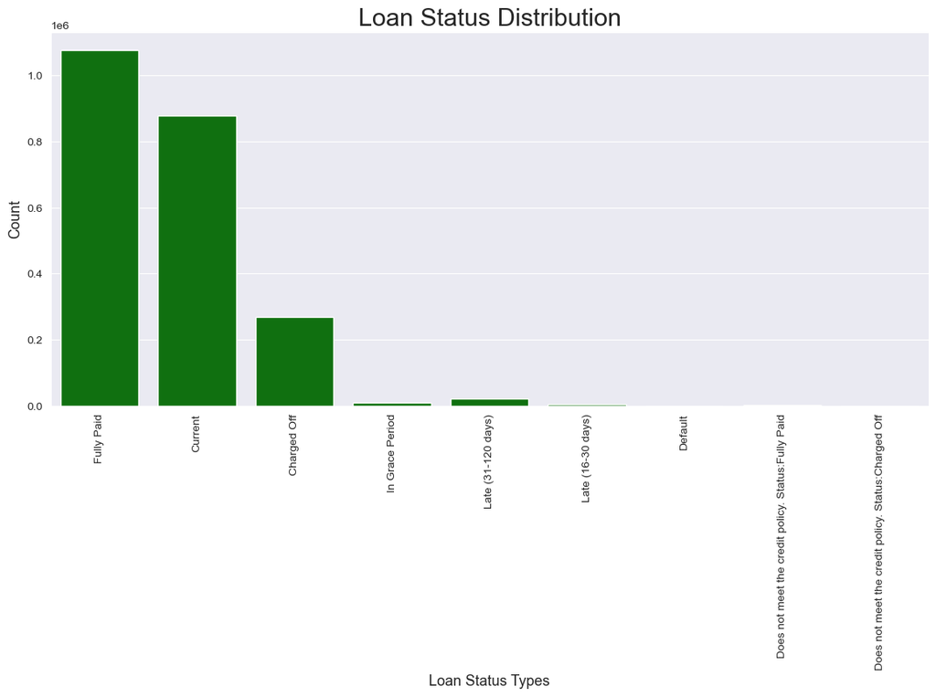

```python
plt.figure(figsize = (14,6))
g = sns.countplot(x="loan_status", data=df, color='green')
g.set_xticklabels(g.get_xticklabels(),rotation=90)
g.set_xlabel("Loan Status Types", fontsize=13)
g.set_ylabel("Count", fontsize=13)
g.set_title("Loan Status Distribution", fontsize=22)
plt.show()
```

#### Next, it would be interesting to understand the reason for borrowing the loan. For this we have taken the column **'purpose'**.

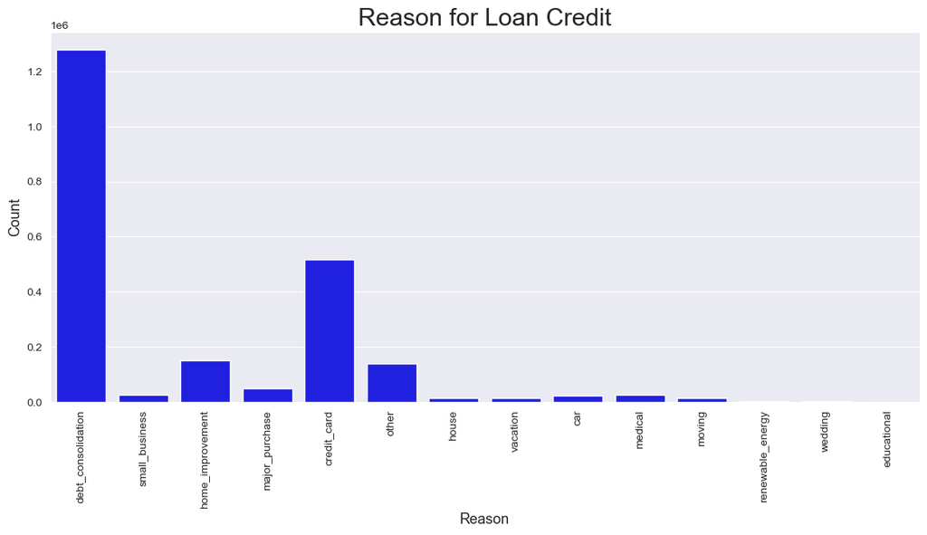

```python
plt.figure(figsize=(14,6))
g = sns.countplot(x='purpose', data=df, color='blue')
g.set_xticklabels(g.get_xticklabels(),rotation=90)
g.set_title("Reason for Loan Credit", fontsize=22)
g.set_xlabel("Reason", fontsize=13)
g.set_ylabel('Count', fontsize=13)
plt.show()
```

#### Debt consolidation and credit card are the main reasons for borrowing a loan.

#### **Loan Status Distribution**

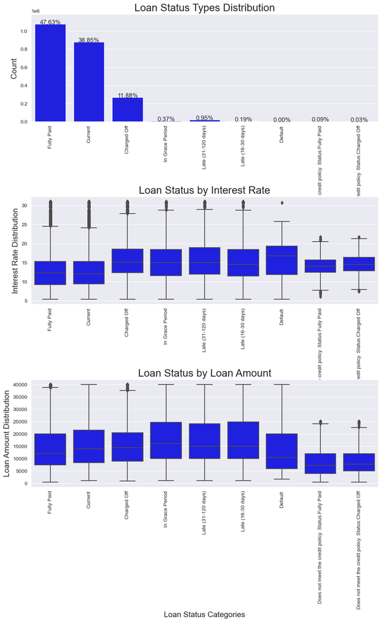

```python
plt.figure(figsize = (12,16))
total = len(df)
plt.subplot(311)
g = sns.countplot(x="loan_status", data=df,
                  color='blue')
g.set_xticklabels(g.get_xticklabels(),rotation=90)
g.set_xlabel("Loan Status Categories", fontsize=12)
g.set_ylabel("Count", fontsize=15)
g.set_title("Loan Status Types Distribution", fontsize=20)
sizes=[]
for p in g.patches:
    height = p.get_height()
    sizes.append(height)
    g.text(p.get_x()+p.get_width()/2.,
            height + 3,
            '{:1.2f}%'.format(height/total*100),
            ha="center", fontsize=12)
g.set_ylim(0, max(sizes) * 1.10)

plt.subplot(312)
g1 = sns.boxplot(x="loan_status", y="int_rate", data=df, color='blue')
g1.set_xticklabels(g1.get_xticklabels(),rotation=90)
g1.set_xlabel("Loan Status Categories", fontsize=12)
g1.set_ylabel("Interest Rate Distribution", fontsize=15)
g1.set_title("Loan Status by Interest Rate", fontsize=20)
plt.subplot(313)
g2 = sns.boxplot(x="loan_status", y="loan_amnt", data=df,
                 color='blue')
g2.set_xticklabels(g2.get_xticklabels(),rotation=90)
g2.set_xlabel("Loan Status Categories", fontsize=15)
g2.set_ylabel("Loan Amount Distribution", fontsize=15)
g2.set_title("Loan Status by Loan Amount", fontsize=20)

plt.subplots_adjust(hspace = 0.7,top = 0.9)

plt.show()
```

## **5.1 Crosstabs**

#### **Purpose by Loan Status**

```python
purp_loan= ['purpose', 'loan_status']
cm = sns.light_palette("green", as_cmap=True)
(round(pd.crosstab(df[purp_loan[0]], df[purp_loan[1]],
                   normalize='columns') * 100,2)).style.background_gradient(cmap = cm)
```

| loan_status purpose | Charged Off | Current | Default | Does not meet the credit policy. Status:Charged Off | Does not meet the credit policy. Status:Fully Paid | Fully Paid | In Grace Period | Late (16-30 days) | Late (31-120 days) |
| --- | --- | --- | --- | --- | --- | --- | --- | --- | --- |
| car | 0.800000 | 1.030000 | 7.500000 | 1.710000 | 2.570000 | 1.160000 | 0.890000 | 0.690000 | 0.890000 |
| credit_card | 18.610000 | 24.460000 | 15.000000 | 9.070000 | 13.630000 | 22.780000 | 19.820000 | 18.850000 | 18.700000 |
| debt_consolidation | 61.440000 | 54.240000 | 52.500000 | 38.370000 | 40.640000 | 57.140000 | 59.250000 | 57.990000 | 58.110000 |
| educational | 0.020000 | 0.000000 | 0.000000 | 4.200000 | 3.270000 | 0.030000 | 0.000000 | 0.000000 | 0.000000 |
| home_improvement | 5.770000 | 6.880000 | 7.500000 | 9.330000 | 7.190000 | 6.690000 | 6.610000 | 7.470000 | 6.710000 |
| house | 0.590000 | 0.750000 | 2.500000 | 1.450000 | 1.660000 | 0.530000 | 0.720000 | 0.970000 | 0.870000 |
| major_purchase | 2.040000 | 2.280000 | 5.000000 | 3.020000 | 5.030000 | 2.220000 | 2.230000 | 2.460000 | 2.650000 |
| medical | 1.260000 | 1.300000 | 5.000000 | 2.890000 | 1.810000 | 1.130000 | 1.260000 | 1.130000 | 1.370000 |
| moving | 0.820000 | 0.640000 | 0.000000 | 1.970000 | 1.560000 | 0.670000 | 0.700000 | 0.990000 | 0.830000 |
| other | 6.100000 | 6.680000 | 5.000000 | 15.900000 | 15.240000 | 5.710000 | 6.760000 | 7.130000 | 7.470000 |
| renewable_energy | 0.080000 | 0.060000 | 0.000000 | 0.130000 | 0.100000 | 0.070000 | 0.010000 | 0.090000 | 0.070000 |
| small_business | 1.710000 | 0.980000 | 0.000000 | 9.460000 | 4.480000 | 1.010000 | 1.320000 | 1.630000 | 1.580000 |
| vacation | 0.650000 | 0.710000 | 0.000000 | 0.790000 | 0.650000 | 0.680000 | 0.440000 | 0.600000 | 0.750000 |
| wedding | 0.100000 | 0.000000 | 0.000000 | 1.710000 | 2.160000 | 0.190000 | 0.000000 | 0.000000 | 0.000000 |

#### **Grade by Loan Status**

```python
purp_loan= ['grade', 'loan_status']
cm = sns.light_palette("green", as_cmap=True)
(round(pd.crosstab(df[purp_loan[0]], df[purp_loan[1]],
                   normalize='columns') * 100,2)).style.background_gradient(cmap = cm)
```

| loan_status grade | Charged Off | Current | Default | Does not meet the credit policy. Status:Charged Off | Does not meet the credit policy. Status:Fully Paid | Fully Paid | In Grace Period | Late (16-30 days) | Late (31-120 days) |
| --- | --- | --- | --- | --- | --- | --- | --- | --- | --- |
| A | 5.290000 | 22.260000 | 12.500000 | 1.050000 | 4.530000 | 20.510000 | 7.490000 | 7.840000 | 6.160000 |
| B | 19.570000 | 29.930000 | 17.500000 | 11.170000 | 13.530000 | 31.590000 | 20.990000 | 22.830000 | 22.300000 |
| C | 31.890000 | 29.110000 | 20.000000 | 19.450000 | 24.200000 | 27.490000 | 35.480000 | 33.940000 | 35.190000 |
| D | 22.730000 | 13.110000 | 32.500000 | 25.890000 | 24.850000 | 12.990000 | 22.510000 | 22.280000 | 22.180000 |
| E | 13.420000 | 4.340000 | 15.000000 | 20.760000 | 19.010000 | 5.350000 | 9.470000 | 9.240000 | 10.090000 |
| F | 5.400000 | 0.970000 | 2.500000 | 12.220000 | 7.750000 | 1.630000 | 2.840000 | 2.970000 | 2.980000 |
| G | 1.700000 | 0.280000 | 0.000000 | 9.460000 | 6.140000 | 0.420000 | 1.210000 | 0.900000 | 1.100000 |

#### **Interest Rate by Grade and Loan Status**

```python
loan_grade = ['loan_status', 'grade']
cm = sns.light_palette("green", as_cmap=True)
round(pd.crosstab(df[loan_grade[0]], df[loan_grade[1]],
            values=df['int_rate'], aggfunc='mean'),2).fillna(0).style.background_gradient(cmap = cm)
```

| grade loan_status | A | B | C | D | E | F | G |
| --- | --- | --- | --- | --- | --- | --- | --- |
| Charged Off | 7.390000 | 10.790000 | 14.080000 | 17.790000 | 21.200000 | 25.100000 | 27.950000 |
| Current | 7.050000 | 10.670000 | 14.320000 | 18.850000 | 23.460000 | 27.380000 | 29.790000 |
| Default | 7.200000 | 11.040000 | 13.870000 | 18.860000 | 24.520000 | 30.740000 | 0.000000 |
| Does not meet the credit policy. Status:Charged Off | 8.300000 | 10.760000 | 12.610000 | 14.480000 | 15.530000 | 17.180000 | 18.860000 |
| Does not meet the credit policy. Status:Fully Paid | 8.090000 | 10.760000 | 12.870000 | 14.440000 | 15.570000 | 17.190000 | 18.930000 |
| Fully Paid | 7.100000 | 10.660000 | 14.000000 | 17.690000 | 21.100000 | 24.800000 | 27.510000 |
| In Grace Period | 7.270000 | 10.700000 | 14.350000 | 18.750000 | 23.390000 | 27.500000 | 29.620000 |
| Late (16-30 days) | 7.190000 | 10.790000 | 14.380000 | 18.910000 | 23.740000 | 27.850000 | 30.140000 |
| Late (31-120 days) | 7.250000 | 10.730000 | 14.360000 | 18.910000 | 23.670000 | 27.920000 | 30.130000 |

#### **Verification Status**

This indicates if the income was verified by LC, not verified, or if the income source was verified.

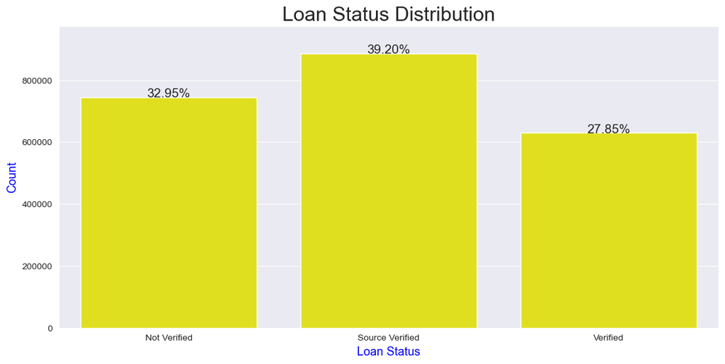

```python
plt.figure(figsize = (13,6))
g = sns.countplot(x="verification_status", data=df, color='yellow')
g.set_xlabel("Loan Status", fontsize=13, color='blue')
g.set_ylabel("Count", fontsize=13, color='blue')
g.set_title("Loan Status Distribution", fontsize=22)
sizes=[]
for p in g.patches:
    height = p.get_height()
    sizes.append(height)
    g.text(p.get_x()+p.get_width()/2.,
            height + 3,
            '{:1.2f}%'.format(height/total*100),
            ha="center", fontsize=14)
g.set_ylim(0, max(sizes) * 1.10)
plt.show()
```

#### Source verified status has the highest distribution.

#### **Loan Status by Verification Status**

```python
loan_verification = ['loan_status', 'verification_status']
cm = sns.light_palette("green", as_cmap=True)
pd.crosstab(df[loan_verification[0]], df[loan_verification[1]],
            normalize='index').style.background_gradient(cmap = cm)
```

| verification_status loan_status | Not Verified | Source Verified | Verified |
| --- | --- | --- | --- |
| Charged Off | 0.221683 | 0.406734 | 0.371583 |
| Current | 0.373559 | 0.398717 | 0.227724 |
| Default | 0.200000 | 0.400000 | 0.400000 |
| Does not meet the credit policy. Status:Charged Off | 0.671485 | 0.107753 | 0.220762 |
| Does not meet the credit policy. Status:Fully Paid | 0.664487 | 0.104628 | 0.230885 |
| Fully Paid | 0.321491 | 0.382671 | 0.295838 |
| In Grace Period | 0.266240 | 0.423661 | 0.310100 |
| Late (16-30 days) | 0.275236 | 0.420556 | 0.304208 |
| Late (31-120 days) | 0.266409 | 0.421531 | 0.312060 |

#### **Installment**

It is the monthly payment owed by the borrower if the loan originates.

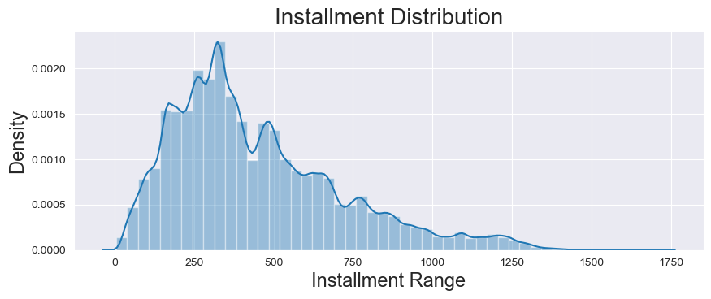

```python
plt.figure(figsize=(10,3.5))
sns.distplot(df['installment'])
plt.title("Installment Distribution", fontsize=20)
plt.xlabel("Installment Range", fontsize=17)
plt.ylabel("Density", fontsize=17)
plt.show()
```

#### We can see the peak of the installments are at monthly ~300USD.

#### **Loan Status by Application Type**

```python
loan_application = ['loan_status', 'application_type']
cm = sns.light_palette("green", as_cmap=True)
pd.crosstab(df[loan_application[0]], df[loan_application[1]]).style.background_gradient(cmap = cm)
```

| application_type loan_status | Individual | Joint App |
| --- | --- | --- |
| Charged Off | 262215 | 6344 |
| Current | 787191 | 91126 |
| Default | 34 | 6 |
| Does not meet the credit policy. Status:Charged Off | 761 | 0 |
| Does not meet the credit policy. Status:Fully Paid | 1988 | 0 |
| Fully Paid | 1057295 | 19456 |
| In Grace Period | 7342 | 1094 |
| Late (16-30 days) | 3843 | 506 |
| Late (31-120 days) | 19289 | 2178 |

#### **Loan Status by Home Ownership**

```python
loan_home = ['loan_status', 'home_ownership']
cm = sns.light_palette("green", as_cmap=True)
round(pd.crosstab(df[loan_home[0]], df[loan_home[1]],
            normalize='index'),2).fillna(0).style.background_gradient(cmap = cm)
```

| home_ownership loan_status | ANY | MORTGAGE | NONE | OTHER | OWN | RENT |
| --- | --- | --- | --- | --- | --- | --- |
| Charged Off | 0.000000 | 0.430000 | 0.000000 | 0.000000 | 0.110000 | 0.460000 |
| Current | 0.000000 | 0.490000 | 0.000000 | 0.000000 | 0.120000 | 0.390000 |
| Default | 0.000000 | 0.420000 | 0.000000 | 0.000000 | 0.200000 | 0.380000 |
| Does not meet the credit policy. Status:Charged Off | 0.000000 | 0.460000 | 0.000000 | 0.010000 | 0.060000 | 0.460000 |
| Does not meet the credit policy. Status:Fully Paid | 0.000000 | 0.460000 | 0.000000 | 0.010000 | 0.070000 | 0.460000 |
| Fully Paid | 0.000000 | 0.510000 | 0.000000 | 0.000000 | 0.110000 | 0.380000 |
| In Grace Period | 0.000000 | 0.480000 | 0.000000 | 0.000000 | 0.110000 | 0.410000 |
| Late (16-30 days) | 0.000000 | 0.440000 | 0.000000 | 0.000000 | 0.130000 | 0.430000 |
| Late (31-120 days) | 0.000000 | 0.430000 | 0.000000 | 0.000000 | 0.130000 | 0.440000 |

#### **Mean Interest Rate by Grade and Sub-Grade**

```python
loan_grade = ['sub_grade', 'grade']
cm = sns.light_palette("green", as_cmap=True)
round(pd.crosstab(df[loan_grade[0]], df[loan_grade[1]],
            values=df['int_rate'], aggfunc='mean'),2).fillna(0).style.background_gradient(cmap = cm)
```

| grade sub_grade | A | B | C | D | E | F | G |
| --- | --- | --- | --- | --- | --- | --- | --- |
| A1 | 5.600000 | 0.000000 | 0.000000 | 0.000000 | 0.000000 | 0.000000 | 0.000000 |
| A2 | 6.550000 | 0.000000 | 0.000000 | 0.000000 | 0.000000 | 0.000000 | 0.000000 |
| A3 | 7.090000 | 0.000000 | 0.000000 | 0.000000 | 0.000000 | 0.000000 | 0.000000 |
| A4 | 7.560000 | 0.000000 | 0.000000 | 0.000000 | 0.000000 | 0.000000 | 0.000000 |
| A5 | 8.200000 | 0.000000 | 0.000000 | 0.000000 | 0.000000 | 0.000000 | 0.000000 |
| B1 | 0.000000 | 9.080000 | 0.000000 | 0.000000 | 0.000000 | 0.000000 | 0.000000 |
| B2 | 0.000000 | 9.970000 | 0.000000 | 0.000000 | 0.000000 | 0.000000 | 0.000000 |
| B3 | 0.000000 | 10.710000 | 0.000000 | 0.000000 | 0.000000 | 0.000000 | 0.000000 |
| B4 | 0.000000 | 11.370000 | 0.000000 | 0.000000 | 0.000000 | 0.000000 | 0.000000 |
| B5 | 0.000000 | 12.010000 | 0.000000 | 0.000000 | 0.000000 | 0.000000 | 0.000000 |
| C1 | 0.000000 | 0.000000 | 12.780000 | 0.000000 | 0.000000 | 0.000000 | 0.000000 |
| C2 | 0.000000 | 0.000000 | 13.540000 | 0.000000 | 0.000000 | 0.000000 | 0.000000 |
| C3 | 0.000000 | 0.000000 | 14.100000 | 0.000000 | 0.000000 | 0.000000 | 0.000000 |
| C4 | 0.000000 | 0.000000 | 14.880000 | 0.000000 | 0.000000 | 0.000000 | 0.000000 |
| C5 | 0.000000 | 0.000000 | 15.770000 | 0.000000 | 0.000000 | 0.000000 | 0.000000 |
| D1 | 0.000000 | 0.000000 | 0.000000 | 16.660000 | 0.000000 | 0.000000 | 0.000000 |
| D2 | 0.000000 | 0.000000 | 0.000000 | 17.600000 | 0.000000 | 0.000000 | 0.000000 |
| D3 | 0.000000 | 0.000000 | 0.000000 | 18.390000 | 0.000000 | 0.000000 | 0.000000 |
| D4 | 0.000000 | 0.000000 | 0.000000 | 19.070000 | 0.000000 | 0.000000 | 0.000000 |
| D5 | 0.000000 | 0.000000 | 0.000000 | 20.060000 | 0.000000 | 0.000000 | 0.000000 |
| E1 | 0.000000 | 0.000000 | 0.000000 | 0.000000 | 20.330000 | 0.000000 | 0.000000 |
| E2 | 0.000000 | 0.000000 | 0.000000 | 0.000000 | 21.010000 | 0.000000 | 0.000000 |
| E3 | 0.000000 | 0.000000 | 0.000000 | 0.000000 | 21.880000 | 0.000000 | 0.000000 |
| E4 | 0.000000 | 0.000000 | 0.000000 | 0.000000 | 22.780000 | 0.000000 | 0.000000 |
| E5 | 0.000000 | 0.000000 | 0.000000 | 0.000000 | 24.110000 | 0.000000 | 0.000000 |
| F1 | 0.000000 | 0.000000 | 0.000000 | 0.000000 | 0.000000 | 24.550000 | 0.000000 |
| F2 | 0.000000 | 0.000000 | 0.000000 | 0.000000 | 0.000000 | 24.990000 | 0.000000 |
| F3 | 0.000000 | 0.000000 | 0.000000 | 0.000000 | 0.000000 | 25.780000 | 0.000000 |
| F4 | 0.000000 | 0.000000 | 0.000000 | 0.000000 | 0.000000 | 26.350000 | 0.000000 |
| F5 | 0.000000 | 0.000000 | 0.000000 | 0.000000 | 0.000000 | 27.100000 | 0.000000 |
| G1 | 0.000000 | 0.000000 | 0.000000 | 0.000000 | 0.000000 | 0.000000 | 27.850000 |
| G2 | 0.000000 | 0.000000 | 0.000000 | 0.000000 | 0.000000 | 0.000000 | 27.650000 |
| G3 | 0.000000 | 0.000000 | 0.000000 | 0.000000 | 0.000000 | 0.000000 | 28.110000 |
| G4 | 0.000000 | 0.000000 | 0.000000 | 0.000000 | 0.000000 | 0.000000 | 28.560000 |
| G5 | 0.000000 | 0.000000 | 0.000000 | 0.000000 | 0.000000 | 0.000000 | 28.810000 |

#### **Employee Title**

Lets look at the employee titles and respective grades and sub-grades allocated to them.

#### **Grades for each employee title**

```python
title_mask = df.emp_title.value_counts()[:20].index.values
cm = sns.light_palette("green", as_cmap=True)
round(pd.crosstab(df[df['emp_title'].isin(title_mask)]['emp_title'],
                  df[df['emp_title'].isin(title_mask)]['sub_grade'],
                  normalize='index') * 100,2).style.background_gradient(cmap = cm)
```

| sub_grade emp_title | A1 | A2 | A3 | A4 | A5 | B1 | B2 | B3 | B4 | B5 | C1 | C2 | C3 | C4 | C5 | D1 | D2 | D3 | D4 | D5 | E1 | E2 | E3 | E4 | E5 | F1 | F2 | F3 | F4 | … |
| --- | --- | --- | --- | --- | --- | --- | --- | --- | --- | --- | --- | --- | --- | --- | --- | --- | --- | --- | --- | --- | --- | --- | --- | --- | --- | --- | --- | --- | --- | --- |
| Accountant | 3.430000 | 3.410000 | 3.450000 | 4.810000 | 5.220000 | 6.340000 | 6.180000 | 5.880000 | 6.180000 | 6.490000 | 6.590000 | 5.650000 | 5.560000 | 5.400000 | 4.840000 | 3.130000 | 2.970000 | 2.970000 | 2.110000 | 1.980000 | 1.410000 | 1.160000 | 0.980000 | 0.790000 | 1.000000 | 0.480000 | 0.290000 | 0.270000 | 0.230000 | … |
| Director | 6.830000 | 3.970000 | 3.970000 | 5.200000 | 5.360000 | 6.150000 | 5.740000 | 6.010000 | 6.350000 | 5.930000 | 6.600000 | 5.080000 | 5.340000 | 5.450000 | 4.240000 | 2.930000 | 2.460000 | 2.190000 | 2.210000 | 1.580000 | 1.100000 | 0.770000 | 0.990000 | 0.990000 | 0.810000 | 0.360000 | 0.310000 | 0.200000 | 0.360000 | … |
| Driver | 2.450000 | 2.280000 | 2.960000 | 3.750000 | 3.940000 | 5.420000 | 5.420000 | 5.440000 | 6.190000 | 6.670000 | 6.740000 | 6.320000 | 5.880000 | 5.960000 | 5.840000 | 4.010000 | 4.020000 | 3.180000 | 2.890000 | 2.390000 | 1.380000 | 1.170000 | 1.210000 | 1.100000 | 1.040000 | 0.490000 | 0.390000 | 0.400000 | 0.290000 | … |
| Engineer | 6.430000 | 4.440000 | 4.490000 | 5.260000 | 5.630000 | 5.980000 | 5.890000 | 6.120000 | 5.890000 | 5.500000 | 6.020000 | 5.600000 | 4.810000 | 4.830000 | 4.650000 | 2.880000 | 2.520000 | 2.620000 | 2.070000 | 1.490000 | 1.440000 | 0.960000 | 0.880000 | 0.710000 | 0.860000 | 0.630000 | 0.370000 | 0.330000 | 0.160000 | … |
| General Manager | 4.180000 | 3.190000 | 2.940000 | 3.970000 | 5.250000 | 5.880000 | 5.960000 | 5.730000 | 5.820000 | 6.380000 | 6.540000 | 6.120000 | 5.620000 | 5.560000 | 5.340000 | 3.420000 | 3.030000 | 2.790000 | 2.370000 | 1.980000 | 1.390000 | 1.260000 | 1.140000 | 0.940000 | 1.040000 | 0.440000 | 0.480000 | 0.300000 | 0.270000 | … |
| Manager | 3.850000 | 3.020000 | 3.290000 | 4.200000 | 4.950000 | 5.530000 | 5.490000 | 5.530000 | 5.990000 | 6.250000 | 6.480000 | 5.860000 | 5.990000 | 5.720000 | 5.390000 | 3.380000 | 3.200000 | 2.800000 | 2.490000 | 2.150000 | 1.500000 | 1.360000 | 1.200000 | 0.920000 | 1.010000 | 0.580000 | 0.380000 | 0.370000 | 0.280000 | … |
| Office Manager | 3.190000 | 3.150000 | 3.260000 | 4.270000 | 4.870000 | 5.430000 | 5.430000 | 5.270000 | 6.000000 | 6.640000 | 6.440000 | 5.580000 | 6.170000 | 5.710000 | 5.560000 | 3.760000 | 3.100000 | 3.170000 | 2.280000 | 2.350000 | 1.550000 | 1.410000 | 1.260000 | 0.750000 | 1.240000 | 0.590000 | 0.330000 | 0.260000 | 0.270000 | … |
| Operations Manager | 3.850000 | 3.080000 | 3.380000 | 4.110000 | 5.120000 | 5.890000 | 5.790000 | 5.320000 | 5.760000 | 6.020000 | 6.580000 | 6.200000 | 5.830000 | 5.740000 | 4.990000 | 3.460000 | 3.210000 | 2.330000 | 2.630000 | 2.250000 | 1.570000 | 1.240000 | 1.320000 | 0.860000 | 1.170000 | 0.600000 | 0.260000 | 0.340000 | 0.330000 | … |
| Owner | 4.560000 | 3.840000 | 3.580000 | 4.460000 | 4.810000 | 6.770000 | 6.240000 | 5.970000 | 6.140000 | 6.040000 | 6.550000 | 5.950000 | 5.200000 | 5.280000 | 4.810000 | 3.560000 | 3.020000 | 2.530000 | 2.080000 | 1.880000 | 1.180000 | 1.130000 | 0.990000 | 0.780000 | 0.770000 | 0.370000 | 0.290000 | 0.280000 | 0.250000 | … |
| President | 7.060000 | 4.560000 | 4.670000 | 5.850000 | 5.470000 | 6.480000 | 6.200000 | 5.590000 | 5.740000 | 5.840000 | 6.760000 | 5.180000 | 4.840000 | 4.800000 | 4.200000 | 2.780000 | 2.420000 | 2.210000 | 1.790000 | 1.450000 | 0.990000 | 0.900000 | 0.950000 | 1.010000 | 0.690000 | 0.350000 | 0.340000 | 0.210000 | 0.090000 | … |
| Project Manager | 5.660000 | 4.010000 | 3.500000 | 4.880000 | 5.700000 | 6.220000 | 5.840000 | 5.690000 | 5.840000 | 6.440000 | 6.260000 | 5.650000 | 5.340000 | 5.300000 | 4.780000 | 2.760000 | 2.540000 | 2.430000 | 2.260000 | 1.970000 | 1.190000 | 1.140000 | 1.110000 | 0.790000 | 0.840000 | 0.500000 | 0.360000 | 0.220000 | 0.190000 | … |
| RN | 4.680000 | 3.450000 | 3.520000 | 4.800000 | 5.220000 | 5.970000 | 6.000000 | 6.130000 | 6.200000 | 6.280000 | 6.050000 | 5.930000 | 5.460000 | 5.680000 | 4.800000 | 3.370000 | 3.040000 | 2.500000 | 2.230000 | 1.640000 | 1.320000 | 1.010000 | 0.990000 | 0.900000 | 0.790000 | 0.500000 | 0.360000 | 0.300000 | 0.220000 | … |
| Registered Nurse | 4.330000 | 3.570000 | 3.730000 | 4.700000 | 5.310000 | 5.780000 | 5.970000 | 6.030000 | 6.280000 | 6.270000 | 6.150000 | 5.400000 | 5.500000 | 5.770000 | 5.280000 | 3.250000 | 2.820000 | 2.510000 | 2.110000 | 1.880000 | 1.420000 | 1.120000 | 1.060000 | 0.790000 | 0.920000 | 0.470000 | 0.350000 | 0.330000 | 0.190000 | … |
| Sales | 3.770000 | 2.920000 | 3.210000 | 3.990000 | 4.880000 | 6.110000 | 5.820000 | 5.640000 | 6.440000 | 6.610000 | 6.610000 | 5.850000 | 6.000000 | 5.800000 | 5.140000 | 3.360000 | 3.200000 | 2.680000 | 2.570000 | 1.920000 | 1.460000 | 1.210000 | 1.040000 | 0.910000 | 0.820000 | 0.390000 | 0.330000 | 0.300000 | 0.240000 | … |
| Supervisor | 2.910000 | 2.530000 | 2.630000 | 3.550000 | 3.980000 | 4.960000 | 5.150000 | 5.510000 | 5.680000 | 6.780000 | 7.070000 | 5.710000 | 6.310000 | 5.840000 | 5.770000 | 3.990000 | 3.640000 | 2.830000 | 2.850000 | 2.380000 | 1.570000 | 1.610000 | 1.420000 | 1.270000 | 1.250000 | 0.710000 | 0.450000 | 0.410000 | 0.280000 | … |
| Teacher | 3.970000 | 3.280000 | 3.520000 | 4.420000 | 4.990000 | 6.100000 | 5.910000 | 5.970000 | 6.250000 | 6.390000 | 6.460000 | 5.770000 | 5.530000 | 5.610000 | 5.210000 | 3.450000 | 3.150000 | 2.610000 | 2.230000 | 1.990000 | 1.390000 | 1.140000 | 1.030000 | 0.840000 | 0.890000 | 0.480000 | 0.300000 | 0.300000 | 0.220000 | … |
| Vice President | 7.410000 | 4.720000 | 4.220000 | 5.410000 | 5.750000 | 5.990000 | 5.360000 | 5.790000 | 5.640000 | 5.750000 | 6.150000 | 5.460000 | 5.580000 | 4.720000 | 4.190000 | 2.880000 | 2.520000 | 2.370000 | 2.080000 | 1.580000 | 1.170000 | 0.990000 | 0.870000 | 0.870000 | 0.650000 | 0.490000 | 0.290000 | 0.290000 | 0.200000 | … |
| manager | 2.540000 | 2.320000 | 2.900000 | 3.460000 | 3.800000 | 5.570000 | 5.040000 | 5.080000 | 6.290000 | 6.630000 | 6.710000 | 6.360000 | 6.270000 | 5.580000 | 5.480000 | 4.390000 | 3.920000 | 2.900000 | 2.750000 | 2.270000 | 1.700000 | 1.420000 | 1.460000 | 1.100000 | 1.050000 | 0.760000 | 0.470000 | 0.470000 | 0.330000 | … |
| owner | 4.230000 | 3.360000 | 3.740000 | 4.110000 | 4.810000 | 6.620000 | 6.240000 | 5.800000 | 6.320000 | 5.910000 | 7.040000 | 5.780000 | 5.550000 | 5.170000 | 5.270000 | 3.550000 | 2.800000 | 2.800000 | 2.430000 | 1.830000 | 1.260000 | 1.320000 | 0.980000 | 0.630000 | 0.670000 | 0.390000 | 0.320000 | 0.320000 | 0.210000 | … |
| teacher | 3.650000 | 3.330000 | 2.970000 | 4.210000 | 5.330000 | 6.200000 | 6.220000 | 6.140000 | 6.230000 | 6.690000 | 6.680000 | 5.530000 | 5.900000 | 5.380000 | 5.230000 | 3.510000 | 2.900000 | 2.600000 | 2.170000 | 1.910000 | 1.420000 | 1.360000 | 1.030000 | 0.880000 | 0.700000 | 0.490000 | 0.330000 | 0.360000 | 0.160000 | … |

#### **Interest rates according to employee lengths**

```python
df.groupby(["emp_length"])['int_rate'].mean().reset_index().T
```

|  | 0 | 1 | 2 | 3 | 4 | 5 | 6 | 7 | 8 | 9 | 10 |
| --- | --- | --- | --- | --- | --- | --- | --- | --- | --- | --- | --- |
| emp_length | 1 year | 10+ years | 2 years | 3 years | 4 years | 5 years | 6 years | 7 years | 8 years | 9 years | < 1 year |
| int_rate | 13.189791 | 13.002788 | 13.127222 | 13.120526 | 13.13112 | 13.141375 | 13.176806 | 13.19482 | 13.097373 | 13.07509 | 13.073689 |

#### **DTI**

DTI is a ratio calculated using the borrower’s total monthly debt payments on the total debt obligations, excluding mortgage and the requested LC loan, divided by the borrower’s self-reported monthly income.

```python
cm = sns.light_palette("green", as_cmap=True)
round((pd.crosstab(df['loan_status'], df['purpose'],
            values=df['dti'], aggfunc='mean')).fillna(0),
      2).style.background_gradient(cmap = cm)
```

| purpose loan_status | car | credit_card | debt_consolidation | educational | home_improvement | house | major_purchase | medical | moving | other | renewable_energy | small_business | vacation | wedding |
| --- | --- | --- | --- | --- | --- | --- | --- | --- | --- | --- | --- | --- | --- | --- |
| Charged Off | 17.470000 | 20.510000 | 20.820000 | 11.050000 | 17.790000 | 16.770000 | 16.400000 | 19.570000 | 18.440000 | 18.630000 | 17.130000 | 15.710000 | 19.100000 | 15.170000 |
| Current | 16.430000 | 19.760000 | 20.280000 | 17.070000 | 18.270000 | 15.460000 | 16.460000 | 19.390000 | 18.500000 | 17.850000 | 17.940000 | 15.820000 | 19.400000 | 13.840000 |
| Default | 13.930000 | 11.090000 | 21.580000 | 0.000000 | 7.500000 | 8.800000 | 12.250000 | 22.740000 | 0.000000 | 13.820000 | 0.000000 | 0.000000 | 0.000000 | 0.000000 |
| Does not meet the credit policy. Status:Charged Off | 11.540000 | 15.140000 | 15.500000 | 13.660000 | 13.350000 | 8.610000 | 12.460000 | 14.960000 | 8.030000 | 14.120000 | 15.770000 | 13.620000 | 15.780000 | 13.650000 |
| Does not meet the credit policy. Status:Fully Paid | 9.920000 | 15.700000 | 15.700000 | 10.190000 | 13.370000 | 10.240000 | 11.540000 | 15.160000 | 12.440000 | 12.680000 | 7.340000 | 11.680000 | 10.600000 | 13.040000 |
| Fully Paid | 14.500000 | 18.060000 | 18.450000 | 11.270000 | 15.650000 | 14.080000 | 14.480000 | 17.080000 | 16.000000 | 16.550000 | 15.890000 | 14.110000 | 17.310000 | 13.830000 |
| In Grace Period | 15.070000 | 21.100000 | 21.470000 | 0.000000 | 17.570000 | 15.140000 | 15.000000 | 18.250000 | 18.630000 | 18.130000 | 25.880000 | 16.280000 | 16.910000 | 0.000000 |
| Late (16-30 days) | 18.010000 | 19.840000 | 20.110000 | 0.000000 | 18.550000 | 15.560000 | 15.800000 | 17.730000 | 18.370000 | 17.860000 | 7.240000 | 17.010000 | 24.200000 | 0.000000 |
| Late (31-120 days) | 16.650000 | 20.730000 | 20.890000 | 0.000000 | 18.190000 | 14.220000 | 16.240000 | 19.500000 | 22.390000 | 18.050000 | 17.850000 | 15.770000 | 20.000000 | 0.000000 |

## **6. Dealing with the missing values**

```python
df.isnull().sum()
```

```
loan_amnt                     33
funded_amnt                   33
funded_amnt_inv               33
term                          33
int_rate                      33
                          ...
settlement_status        2226455
settlement_date          2226455
settlement_amount        2226455
settlement_percentage    2226455
settlement_term          2226455
Length: 124, dtype: int64
```

```python
df.isnull().mean()
```

```
loan_amnt                0.000015
funded_amnt              0.000015
funded_amnt_inv          0.000015
term                     0.000015
int_rate                 0.000015
                           ...
settlement_status        0.984852
settlement_date          0.984852
settlement_amount        0.984852
settlement_percentage    0.984852
settlement_term          0.984852
Length: 124, dtype: float64
```

```python
df.head()
```

|  | loan_amnt | funded_amnt | funded_amnt_inv | term | int_rate | installment | grade | sub_grade | emp_title | emp_length | home_ownership | annual_inc | verification_status | issue_d | loan_status | pymnt_plan | url | purpose | title | zip_code | addr_state | dti | delinq_2yrs | earliest_cr_line | fico_range_low | fico_range_high | inq_last_6mths | open_acc | pub_rec | … |
| --- | --- | --- | --- | --- | --- | --- | --- | --- | --- | --- | --- | --- | --- | --- | --- | --- | --- | --- | --- | --- | --- | --- | --- | --- | --- | --- | --- | --- | --- | --- |
| 0 | 3600.0 | 3600.0 | 3600.0 | 36 months | 13.99 | 123.03 | C | C4 | leadman | 10+ years | MORTGAGE | 55000.0 | Not Verified | Dec-2015 | Fully Paid | n | https://lendingclub.com/browse/loanDetail.acti... | debt_consolidation | Debt consolidation | 190xx | PA | 5.91 | 0.0 | Aug-2003 | 675.0 | 679.0 | 1.0 | 7.0 | 0.0 | … |
| 1 | 24700.0 | 24700.0 | 24700.0 | 36 months | 11.99 | 820.28 | C | C1 | Engineer | 10+ years | MORTGAGE | 65000.0 | Not Verified | Dec-2015 | Fully Paid | n | https://lendingclub.com/browse/loanDetail.acti... | small_business | Business | 577xx | SD | 16.06 | 1.0 | Dec-1999 | 715.0 | 719.0 | 4.0 | 22.0 | 0.0 | … |
| 2 | 20000.0 | 20000.0 | 20000.0 | 60 months | 10.78 | 432.66 | B | B4 | truck driver | 10+ years | MORTGAGE | 63000.0 | Not Verified | Dec-2015 | Fully Paid | n | https://lendingclub.com/browse/loanDetail.acti... | home_improvement | NaN | 605xx | IL | 10.78 | 0.0 | Aug-2000 | 695.0 | 699.0 | 0.0 | 6.0 | 0.0 | … |
| 3 | 35000.0 | 35000.0 | 35000.0 | 60 months | 14.85 | 829.90 | C | C5 | Information Systems Officer | 10+ years | MORTGAGE | 110000.0 | Source Verified | Dec-2015 | Current | n | https://lendingclub.com/browse/loanDetail.acti... | debt_consolidation | Debt consolidation | 076xx | NJ | 17.06 | 0.0 | Sep-2008 | 785.0 | 789.0 | 0.0 | 13.0 | 0.0 | … |
| 4 | 10400.0 | 10400.0 | 10400.0 | 60 months | 22.45 | 289.91 | F | F1 | Contract Specialist | 3 years | MORTGAGE | 104433.0 | Source Verified | Dec-2015 | Fully Paid | n | https://lendingclub.com/browse/loanDetail.acti... | major_purchase | Major purchase | 174xx | PA | 25.37 | 1.0 | Jun-1998 | 695.0 | 699.0 | 3.0 | 12.0 | 0.0 | … |

#### Dropping columns containing either 40% or more than 40% NaN values.

```python
perc = 40.0
min_count =  int(((100-perc)/100)*df.shape[0] + 1)
mod_df = df.dropna( axis=1,
                thresh=min_count)
print("Modified Dataframe : ")
print(mod_df)
```

[output not shown]

[output cut: 325 more lines]

```python
mod_df.isnull().mean()
```

```
loan_amnt                     0.000015
funded_amnt                   0.000015
funded_amnt_inv               0.000015
term                          0.000015
int_rate                      0.000015
                                ...
total_bc_limit                0.022145
total_il_high_credit_limit    0.031101
hardship_flag                 0.000015
disbursement_method           0.000015
debt_settlement_flag          0.000015
Length: 101, dtype: float64
```

```python
mod_df.head()
```

|  | loan_amnt | funded_amnt | funded_amnt_inv | term | int_rate | installment | grade | sub_grade | emp_title | emp_length | home_ownership | annual_inc | verification_status | issue_d | loan_status | pymnt_plan | url | purpose | title | zip_code | addr_state | dti | delinq_2yrs | earliest_cr_line | fico_range_low | fico_range_high | inq_last_6mths | open_acc | pub_rec | … |
| --- | --- | --- | --- | --- | --- | --- | --- | --- | --- | --- | --- | --- | --- | --- | --- | --- | --- | --- | --- | --- | --- | --- | --- | --- | --- | --- | --- | --- | --- | --- |
| 0 | 3600.0 | 3600.0 | 3600.0 | 36 months | 13.99 | 123.03 | C | C4 | leadman | 10+ years | MORTGAGE | 55000.0 | Not Verified | Dec-2015 | Fully Paid | n | https://lendingclub.com/browse/loanDetail.acti... | debt_consolidation | Debt consolidation | 190xx | PA | 5.91 | 0.0 | Aug-2003 | 675.0 | 679.0 | 1.0 | 7.0 | 0.0 | … |
| 1 | 24700.0 | 24700.0 | 24700.0 | 36 months | 11.99 | 820.28 | C | C1 | Engineer | 10+ years | MORTGAGE | 65000.0 | Not Verified | Dec-2015 | Fully Paid | n | https://lendingclub.com/browse/loanDetail.acti... | small_business | Business | 577xx | SD | 16.06 | 1.0 | Dec-1999 | 715.0 | 719.0 | 4.0 | 22.0 | 0.0 | … |
| 2 | 20000.0 | 20000.0 | 20000.0 | 60 months | 10.78 | 432.66 | B | B4 | truck driver | 10+ years | MORTGAGE | 63000.0 | Not Verified | Dec-2015 | Fully Paid | n | https://lendingclub.com/browse/loanDetail.acti... | home_improvement | NaN | 605xx | IL | 10.78 | 0.0 | Aug-2000 | 695.0 | 699.0 | 0.0 | 6.0 | 0.0 | … |
| 3 | 35000.0 | 35000.0 | 35000.0 | 60 months | 14.85 | 829.90 | C | C5 | Information Systems Officer | 10+ years | MORTGAGE | 110000.0 | Source Verified | Dec-2015 | Current | n | https://lendingclub.com/browse/loanDetail.acti... | debt_consolidation | Debt consolidation | 076xx | NJ | 17.06 | 0.0 | Sep-2008 | 785.0 | 789.0 | 0.0 | 13.0 | 0.0 | … |
| 4 | 10400.0 | 10400.0 | 10400.0 | 60 months | 22.45 | 289.91 | F | F1 | Contract Specialist | 3 years | MORTGAGE | 104433.0 | Source Verified | Dec-2015 | Fully Paid | n | https://lendingclub.com/browse/loanDetail.acti... | major_purchase | Major purchase | 174xx | PA | 25.37 | 1.0 | Jun-1998 | 695.0 | 699.0 | 3.0 | 12.0 | 0.0 | … |

## **7. BUSINESS CASE 1**

#### **Problem Statement:** Build a model to predict the probability of default for the applicants on the lending club app. Follow the ML pipeline of data cleaning, feature engineering, model training, K fold validation, Model diagnostics, and model selection.Try out the whole suite of classifier models that are available in scikit-learn.

#### **To predict if a borrower will clear his/ her loan, we chose the following variables:**

**Independent Variables:**

*home_ownership :* status provided by the borrower during registration or obtained from the credit report, *emp_length:* Employment length in Years, *loan_amnt:* the listed amount of loan applied for by the borrower, *grade*, *annual_inc:* the self reported annual income provided by the borrower during registration, *int_rate:* Interest Rate on the loan, *term:* Number of payments on the loan (in months), *fico_range_high:* The upper boundry range the borowwer's FICO at loan originates belongs to.

**Dependent Variable**

*loan_status:* Current state of the loan

#### **Summary:** In 2012, LendingClub reached a $1 billion loan milestone; the company facilitated these loans through three different vehicles: notes, certificates, and whole loan sales. Through its online standard program loan division, it offered these three or five-year unsecured personal loans to borrowers with a FICO range of at least 660 who met the other credit criteria.Applicants specified the amounts they wanted to borrow and provided information about their financial situation, employment, and intended use of the loans. Using the online platform, investors could browse notes and decide which ones to fund. The most common reasons for borrowing were debt consolidation, credit card debt refinance, and home renovation.LendingClub assigned grades ranging from A to G, which are further subdivided into sub-grades 1 to 5. For each entry, the data includes over 100 descriptive features such as application ID, credit score, loan amount, purpose, and so on.To predict new data with a reassuring level of confidence, the target variable is "loan status." Several models have been trained to classify a new loan application as default or repayment based on this target variable.

```python
df1 = mod_df[['home_ownership','emp_length','loan_amnt', 'grade', 'annual_inc','loan_status','int_rate','term','fico_range_high']]
df1.head()
```

|  | home_ownership | emp_length | loan_amnt | grade | annual_inc | loan_status | int_rate | term | fico_range_high |
| --- | --- | --- | --- | --- | --- | --- | --- | --- | --- |
| 0 | MORTGAGE | 10+ years | 3600.0 | C | 55000.0 | Fully Paid | 13.99 | 36 months | 679.0 |
| 1 | MORTGAGE | 10+ years | 24700.0 | C | 65000.0 | Fully Paid | 11.99 | 36 months | 719.0 |
| 2 | MORTGAGE | 10+ years | 20000.0 | B | 63000.0 | Fully Paid | 10.78 | 60 months | 699.0 |
| 3 | MORTGAGE | 10+ years | 35000.0 | C | 110000.0 | Current | 14.85 | 60 months | 789.0 |
| 4 | MORTGAGE | 3 years | 10400.0 | F | 104433.0 | Fully Paid | 22.45 | 60 months | 699.0 |

```python
df1.info()
```

```
<class 'pandas.core.frame.DataFrame'>
RangeIndex: 2260701 entries, 0 to 2260700
Data columns (total 9 columns):
 #   Column           Dtype
---  ------           -----
 0   home_ownership   object
 1   emp_length       object
 2   loan_amnt        float64
 3   grade            object
 4   annual_inc       float64
 5   loan_status      object
 6   int_rate         float64
 7   term             object
 8   fico_range_high  float64
dtypes: float64(4), object(5)
memory usage: 155.2+ MB
```

```python
pd.value_counts(df1.loan_status)
```

```
Fully Paid                                             1076751
Current                                                 878317
Charged Off                                             268559
Late (31-120 days)                                       21467
In Grace Period                                           8436
Late (16-30 days)                                         4349
Does not meet the credit policy. Status:Fully Paid        1988
Does not meet the credit policy. Status:Charged Off        761
Default                                                     40
Name: loan_status, dtype: int64
```

#### For analysis purpose, we will look into fully paid and charged off clients.

```python
df1 = df1.loc[df1['loan_status'].isin(['Fully Paid','Charged Off'])]
pd.value_counts(df1.loan_status)
```

```
Fully Paid     1076751
Charged Off     268559
Name: loan_status, dtype: int64
```

#### Classifying variables into categorical and numerical for further processes

```python
cat_cols= ['grade','loan_status','home_ownership','emp_length','term']
num_cols=['loan_amnt', 'annual_inc','int_rate','fico_range_high']
```

## **7.1 Encoding Categorical Variables**

```python
le= LabelEncoder()

for col in cat_cols:
    df1[col] = le.fit_transform(df1[col].astype(str))

df1.head()
```

|  | home_ownership | emp_length | loan_amnt | grade | annual_inc | loan_status | int_rate | term | fico_range_high |
| --- | --- | --- | --- | --- | --- | --- | --- | --- | --- |
| 0 | 1 | 1 | 3600.0 | 2 | 55000.0 | 1 | 13.99 | 0 | 679.0 |
| 1 | 1 | 1 | 24700.0 | 2 | 65000.0 | 1 | 11.99 | 0 | 719.0 |
| 2 | 1 | 1 | 20000.0 | 1 | 63000.0 | 1 | 10.78 | 1 | 699.0 |
| 4 | 1 | 3 | 10400.0 | 5 | 104433.0 | 1 | 22.45 | 1 | 699.0 |
| 5 | 5 | 4 | 11950.0 | 2 | 34000.0 | 1 | 13.44 | 0 | 694.0 |

## **7.2 Imputing missing values**

```python
lr= LinearRegression()

imputer = IterativeImputer(random_state=42, estimator=lr, max_iter=10, n_nearest_features=2, imputation_order = 'roman')
df1_final = imputer.fit_transform(df1)

df1_final = pd.DataFrame(df1_final, columns = df1.columns)
```

```python
df1_final.isnull().sum()
```

```
home_ownership     0
emp_length         0
loan_amnt          0
grade              0
annual_inc         0
loan_status        0
int_rate           0
term               0
fico_range_high    0
dtype: int64
```

```python
df1_final.sample(5)
```

|  | home_ownership | emp_length | loan_amnt | grade | annual_inc | loan_status | int_rate | term | fico_range_high |
| --- | --- | --- | --- | --- | --- | --- | --- | --- | --- |
| 603391 | 1.0 | 1.0 | 32000.0 | 1.0 | 82000.0 | 1.0 | 10.75 | 0.0 | 679.0 |
| 1139328 | 1.0 | 0.0 | 6000.0 | 3.0 | 48360.0 | 1.0 | 18.75 | 0.0 | 694.0 |
| 424207 | 4.0 | 1.0 | 24000.0 | 4.0 | 66843.0 | 1.0 | 25.82 | 0.0 | 689.0 |
| 524380 | 5.0 | 2.0 | 20000.0 | 1.0 | 65000.0 | 1.0 | 10.91 | 0.0 | 689.0 |
| 1120503 | 1.0 | 9.0 | 10000.0 | 0.0 | 51000.0 | 1.0 | 7.90 | 0.0 | 754.0 |

## **7.3 Correlation Matrix**

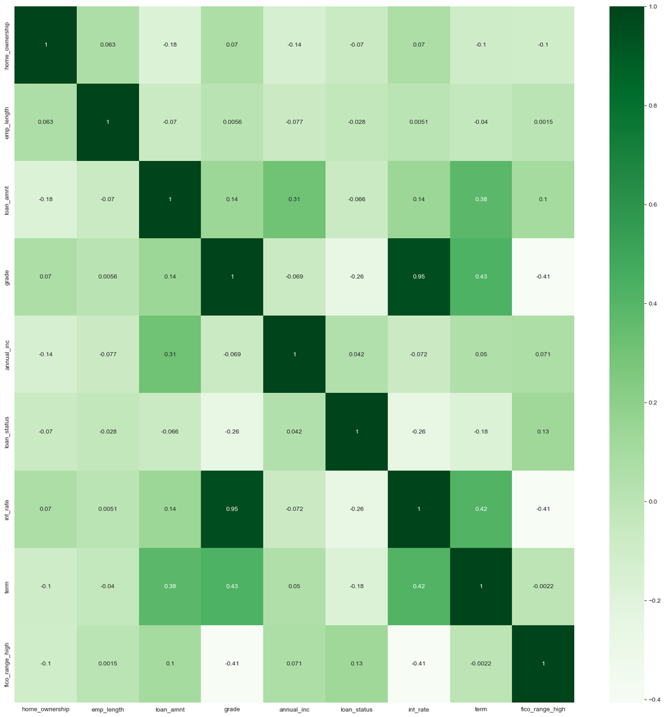

```python
plt.figure(figsize=(20,20))
sns.heatmap(df1_final.corr(), annot=True, cmap="Greens")
```

#### Checking the coefficients

```python
cor = df1_final.corr()
cor.loc[:,:] = np.tril(cor, k=-1) # below main lower triangle of an array
cor = cor.stack()
cor[(cor > 0.1) | (cor < -0.1)]
```

```
loan_amnt        home_ownership   -0.180640
grade            loan_amnt         0.142023
annual_inc       home_ownership   -0.143513
                 loan_amnt         0.311794
loan_status      grade            -0.261525
int_rate         loan_amnt         0.141673
                 grade             0.953275
                 loan_status      -0.258792
term             home_ownership   -0.101890
                 loan_amnt         0.380905
                 grade             0.425297
                 loan_status      -0.176096
                 int_rate          0.417230
fico_range_high  home_ownership   -0.104767
                 loan_amnt         0.100983
                 grade            -0.406472
                 loan_status       0.130682
                 int_rate         -0.405364
dtype: float64
```

## **7.4 Spliting the data into test and train**

```python
X= df1_final[['loan_amnt', 'annual_inc','int_rate','fico_range_high',
              'grade','home_ownership','emp_length','term']]

y= df1_final['loan_status']
X_train, X_test,y_train,y_test= train_test_split(X,y, test_size=0.2,random_state=42)
```

## **7.5 Standardizing numerical data**

```python
ind_num_cols= ['loan_amnt',  'annual_inc','int_rate','fico_range_high']
ss= StandardScaler()
X_train[ind_num_cols]= ss.fit_transform(X_train[ind_num_cols])
X_test[ind_num_cols]= ss.transform(X_test[ind_num_cols])
X_train
```

|  | loan_amnt | annual_inc | int_rate | fico_range_high | grade | home_ownership | emp_length | term |
| --- | --- | --- | --- | --- | --- | --- | --- | --- |
| 690509 | -0.736162 | 0.196593 | -1.415759 | 0.747491 | 0.0 | 5.0 | 0.0 | 0.0 |
| 907486 | 1.214316 | 0.053675 | 2.433070 | -0.665236 | 4.0 | 5.0 | 6.0 | 0.0 |
| 87973 | 1.240131 | 0.768265 | -0.115337 | 0.433552 | 2.0 | 5.0 | 1.0 | 0.0 |
| 317614 | -0.506694 | -0.660915 | 0.018900 | -0.822206 | 2.0 | 5.0 | 4.0 | 0.0 |
| 1210762 | 1.558518 | 2.268903 | -0.471904 | -0.351297 | 1.0 | 1.0 | 5.0 | 1.0 |
| ... | ... | ... | ... | ... | ... | ... | ... | ... |
| 110268 | 0.755380 | -0.232161 | -0.471904 | -0.979176 | 1.0 | 5.0 | 2.0 | 0.0 |
| 259178 | -0.277226 | 0.339511 | -1.122115 | -0.351297 | 0.0 | 4.0 | 5.0 | 0.0 |
| 131932 | 0.411178 | -0.446538 | -0.681650 | 0.433552 | 1.0 | 4.0 | 8.0 | 0.0 |
| 671155 | -1.011523 | -0.546580 | 0.530679 | -0.508267 | 3.0 | 5.0 | 10.0 | 0.0 |
| 121958 | -0.277226 | -0.046367 | -1.661161 | 2.003250 | 0.0 | 1.0 | 9.0 | 0.0 |

1076248 rows × 8 columns

## **7.6 Training the data**

```python
model_start = time.time()
```

```python
key= ['LogisticRegression', 'DecisionTreeClassifier', 'DecisionTreeRegressor', 'GaussianNB', 'LGBMClassifier', 'KNeighborsClassifier']

value= [LogisticRegression(), DecisionTreeClassifier(), DecisionTreeRegressor(), GaussianNB(), LGBMClassifier(), KNeighborsClassifier()]

models= dict(zip(key, value))

#key = ['RandomForestClassifier', 'SVC', 'CatBoostClassifier', 'XGBClassifier']
#values = [RandomForestClassifier(), SVC(), CatBoostClassifier(verbose=False), XGBClassifier()]
#models taking time: RandomForestClassifier, CatBoostClassifier, SVC
```

```python
models
```

```
{'LogisticRegression': LogisticRegression(),
 'DecisionTreeClassifier': DecisionTreeClassifier(),
 'DecisionTreeRegressor': DecisionTreeRegressor(),
 'GaussianNB': GaussianNB(),
 'LGBMClassifier': LGBMClassifier(),
 'KNeighborsClassifier': KNeighborsClassifier()}
```

```python
scores=[]
for key,value in models.items():
    score= -1*cross_val_score(value, X,y, cv=5, scoring='neg_mean_absolute_error')
    scores.append(score)
    print(key, score.mean())
```

```
LogisticRegression 0.19968780429789415
DecisionTreeClassifier 0.31458028261144266
DecisionTreeRegressor 0.3068951341007968
GaussianNB 0.2099902624673867
LGBMClassifier 0.19942689788970572
KNeighborsClassifier 0.2306509280388907
```

```python
accuracy_scores=[]
for key,value in models.items():
    value.fit(X_train,y_train)
    y_pred= value.predict(X_test)
    accuracy= value.score(X_test,y_test)

    accuracy_scores.append(accuracy)
    print(key, accuracy)
```

```
LogisticRegression 0.8015215823862158
DecisionTreeClassifier 0.6963673800090685
DecisionTreeRegressor -0.897112946423325
GaussianNB 0.7616274315956917
LGBMClassifier 0.8035917372204175
KNeighborsClassifier 0.7730151414915521
```

```python
model_end = time.time()
```

```python
model_total_time = model_end - model_start
```

#### From the mean scores and accuracy scores, it can be seen that the Logistic Regression and LGBMClassifier are the best models.

## **7.7 Model Diagnostics**

## **7.7.1 Logistic Regression Model**

```python
logis= LogisticRegression(random_state=42)
logis.fit(X_train,y_train)
y_pred= logis.predict(X_test)

conf_m = confusion_matrix(y_test,y_pred)
print('The confusion Matrix: \n', conf_m)

clas_report = classification_report(y_test,y_pred)
print('\n\n\n Classification report: \n', clas_report)

p_pred = logis.predict_proba(X)
print('\n\n\n The predicted probability: \n',p_pred)

y_pred = logis.predict(X)
print('\n\n\n Model Prediction: \n',y_pred)

score_ = logis.score(X, y)
print('\n\n\n Model Score :\n',score)
```

```
The confusion Matrix:
 [[  3777  49677]
 [  3726 211882]]



 Classification report:
               precision    recall  f1-score   support

         0.0       0.50      0.07      0.12     53454
         1.0       0.81      0.98      0.89    215608

    accuracy                           0.80    269062
   macro avg       0.66      0.53      0.51    269062
weighted avg       0.75      0.80      0.74    269062




 The predicted probability:
 [[0. 1.]
 [0. 1.]
 [0. 1.]
 ...
 [0. 1.]
 [0. 1.]
 [0. 1.]]



 Model Prediction:
 [1. 1. 1. ... 1. 1. 1.]



 Model Score :
 [0.2262787  0.22998788 0.23114375 0.23147825 0.23436606]
```

#### **Tuning the hyperparameters**

```python
# define dataset
X, y = make_blobs(n_samples=1000, centers=2, n_features=100, cluster_std=20)
# define models and parameters
model = LogisticRegression(verbose = False)
solvers = ['newton-cg', 'lbfgs', 'liblinear']
penalty = ['l2']
c_values = [100, 10, 1.0, 0.1, 0.01]
# define grid search
grid = dict(solver=solvers,penalty=penalty,C=c_values)
cv = RepeatedStratifiedKFold(n_splits=10, n_repeats=3, random_state=1)
grid_search = GridSearchCV(estimator=model, param_grid=grid, n_jobs=-1, cv=cv, scoring='accuracy',error_score=0)
logis_clf = grid_search.fit(X, y)
```

```python
logis_clf.best_estimator_
```

```
LogisticRegression(C=0.01, solver='liblinear', verbose=False)
```

```python
logis_clf.best_score_
```

```
0.9520000000000001
```

#### After tuning the hyperparameters, the model has been fitted to get the probability of the test data.

```python
logis_clf.best_estimator_.fit(X_train,y_train)
y_pred= logis_clf.best_estimator_.predict(X_test)

print(confusion_matrix(y_test, y_pred))
print(classification_report(y_test, y_pred))
```

```
[[  3737  49717]
 [  3685 211923]]
              precision    recall  f1-score   support

         0.0       0.50      0.07      0.12     53454
         1.0       0.81      0.98      0.89    215608

    accuracy                           0.80    269062
   macro avg       0.66      0.53      0.51    269062
weighted avg       0.75      0.80      0.74    269062
```

#### **Plotting the confusion matrix for logistic regression model**

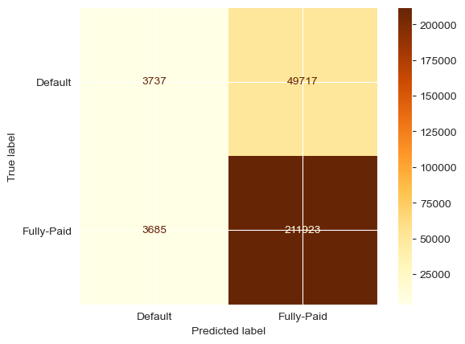

```python
disp = plot_confusion_matrix(
    logis_clf, X_test, y_test,
    cmap='YlOrBr', values_format='d',
    display_labels=['Default', 'Fully-Paid']
)
```

#### **Plotting the ROC curve for logistic regression model**

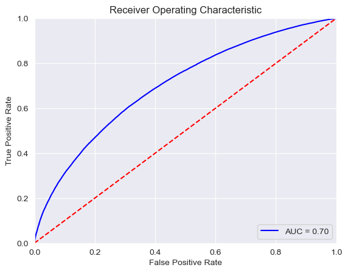

```python
probs = logis_clf.predict_proba(X_test)
preds = probs[:,1]
fpr, tpr, threshold = metrics.roc_curve(y_test, preds)
roc_auc = metrics.auc(fpr, tpr)

plt.title('Receiver Operating Characteristic')
plt.plot(fpr, tpr, 'b', label = 'AUC = %0.2f' % roc_auc)
plt.legend(loc = 'lower right')
plt.plot([0, 1], [0, 1],'r--')
plt.xlim([0, 1])
plt.ylim([0, 1])
plt.ylabel('True Positive Rate')
plt.xlabel('False Positive Rate')
plt.show()
```

## **7.7.2 LightGBM Classification Model**

```python
lgbm= LGBMClassifier(random_state=42)
lgbm.fit(X_train,y_train)
y_pred= lgbm.predict(X_test)

print(confusion_matrix(y_test,y_pred))
print(classification_report(y_test,y_pred))
```

```
[[  3079  50375]
 [  2498 213110]]
              precision    recall  f1-score   support

         0.0       0.55      0.06      0.10     53454
         1.0       0.81      0.99      0.89    215608

    accuracy                           0.80    269062
   macro avg       0.68      0.52      0.50    269062
weighted avg       0.76      0.80      0.73    269062
```

#### **Tuning the hyperparameters**

```python
lgbm_params = {
 'colsample_bytree': [0.6,0.8,1.0],
 'learning_rate': [0.033,0.057,0.1],
 'max_depth': [3,4,5,6],
 'min_child_weight': [1,5,10,12],
 'n_estimators': [150,300,450,600],
 'num_leaves': [10,20,30],
 'subsample': [0.6,0.8,1.0]
 }

lgbm= LGBMClassifier(**lgbm_params)

lgbm
```

```
LGBMClassifier(colsample_bytree=[0.6, 0.8, 1.0],
               learning_rate=[0.033, 0.057, 0.1], max_depth=[3, 4, 5, 6],
               min_child_weight=[1, 5, 10, 12],
               n_estimators=[150, 300, 450, 600], num_leaves=[10, 20, 30],
               subsample=[0.6, 0.8, 1.0])
```

```python
lgbm_clf= RandomizedSearchCV(lgbm, param_distributions=lgbm_params, cv = 5, n_iter=5, verbose=1)

lgbm_clf.fit(X,y)
```

```
Fitting 5 folds for each of 5 candidates, totalling 25 fits
```

```
RandomizedSearchCV(cv=5,
                   estimator=LGBMClassifier(colsample_bytree=[0.6, 0.8, 1.0],
                                            learning_rate=[0.033, 0.057, 0.1],
                                            max_depth=[3, 4, 5, 6],
                                            min_child_weight=[1, 5, 10, 12],
                                            n_estimators=[150, 300, 450, 600],
                                            num_leaves=[10, 20, 30],
                                            subsample=[0.6, 0.8, 1.0]),
                   n_iter=5,
                   param_distributions={'colsample_bytree': [0.6, 0.8, 1.0],
                                        'learning_rate': [0.033, 0.057, 0.1],
                                        'max_depth': [3, 4, 5, 6],
                                        'min_child_weight': [1, 5, 10, 12],
                                        'n_estimators': [150, 300, 450, 600],
                                        'num_leaves': [10, 20, 30],
                                        'subsample': [0.6, 0.8, 1.0]},
                   verbose=1)
```

```python
lgbm_clf.best_estimator_
```

```
LGBMClassifier(colsample_bytree=0.8, learning_rate=0.033, max_depth=4,
               min_child_weight=1, n_estimators=450, num_leaves=20,
               subsample=0.6)
```

```python
lgbm_clf.best_score_
```

```
0.9349999999999999
```

After tuning the hyperparameters, the model has been fitted to get the probability of the test data.

```python
lgbm_clf.best_estimator_.fit(X_train,y_train)
y_pred= lgbm_clf.best_estimator_.predict(X_test)

print(confusion_matrix(y_test, y_pred))
print(classification_report(y_test, y_pred))
```

```
[[  2940  50514]
 [  2385 213223]]
              precision    recall  f1-score   support

         0.0       0.55      0.06      0.10     53454
         1.0       0.81      0.99      0.89    215608

    accuracy                           0.80    269062
   macro avg       0.68      0.52      0.49    269062
weighted avg       0.76      0.80      0.73    269062
```

#### **Plotting the confusion matrix for LightGBM classification model**

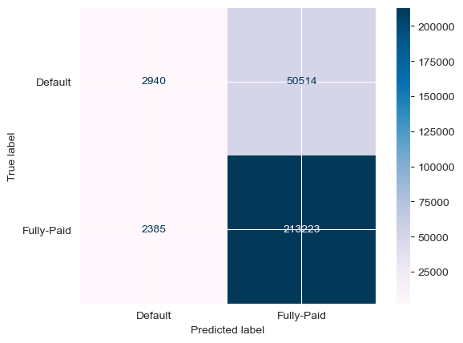

```python
disp = plot_confusion_matrix(
    lgbm_clf, X_test, y_test,
    cmap='PuBu', values_format='d',
    display_labels=['Default', 'Fully-Paid']
)
```

#### **Plotting the ROC curve for Lightgbm classification model**

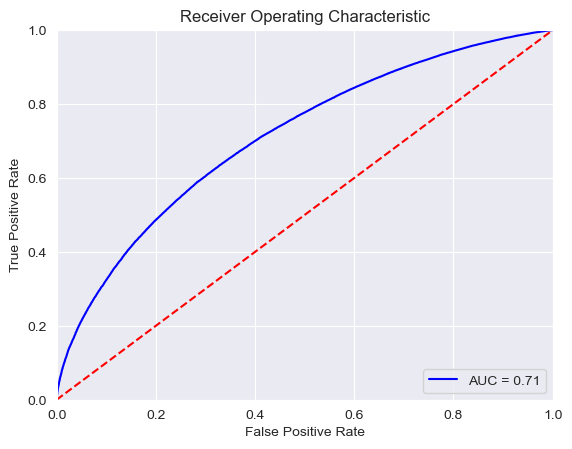

```python
probs = lgbm_clf.predict_proba(X_test)
preds = probs[:,1]
fpr, tpr, threshold = metrics.roc_curve(y_test, preds)
roc_auc = metrics.auc(fpr, tpr)

plt.title('Receiver Operating Characteristic')
plt.plot(fpr, tpr, 'b', label = 'AUC = %0.2f' % roc_auc)
plt.legend(loc = 'lower right')
plt.plot([0, 1], [0, 1],'r--')
plt.xlim([0, 1])
plt.ylim([0, 1])
plt.ylabel('True Positive Rate')
plt.xlabel('False Positive Rate')
plt.show()
```

## **7.8 Model comparison**

```python
ml_models = {
    'Logistic Regression': logis_clf,
    'LightGBM': lgbm_clf,
}

for model in ml_models:
    print(f"{model.upper():{30}} roc_auc_score: {roc_auc_score(y_test, ml_models[model].predict(X_test)):.3f}")
```

```
LOGISTIC REGRESSION            roc_auc_score: 0.526
LIGHTGBM                       roc_auc_score: 0.522
```

## **8. BUSINESS CASE 2**

#### **Problem Statement:** Defining a business case for building a linear regression model. Define Y and choose appropriate independent variables such that there should be a sound business reason to do this .Defining the use context for such a model clearly. Presenting the model and quantify the benefits of the model

#### **Business Model:** To predict the loan amount that can be borrowed.

#### **To predict how much loan can be borrowed, we chose the following variables:**

**Independent Variables:** Term, interest rate, installment, employment length, home ownership, annual income, purpose, application type, and FICO range (low and high)

**Dependent Variable**

*loan_amnt:* the listed amount of loan applied for by the borrower

#### **Use Context:** A customer has approached Lending Club and requested a loan. Lending Club will collect the following information from her/him: Employee history, homeownership, annual income, the reason for the loan, loan type, high and low fico range, and so on.Investors can analyze the loan amount that it can provide, the interest rate, and the monthly installments based on the data shared by a customer and classify it as either default or repay.Based on the independent variables mentioned above, the model is designed to calculate an estimated loan that can be given to a customer.

```python
column = (mod_df.columns.values.tolist())
print(column)
```

```
['loan_amnt', 'funded_amnt', 'funded_amnt_inv', 'term', 'int_rate', 'installment', 'grade', 'sub_grade', 'emp_title', 'emp_length', 'home_ownership', 'annual_inc', 'verification_status', 'issue_d', 'loan_status', 'pymnt_plan', 'url', 'purpose', 'title', 'zip_code', 'addr_state', 'dti', 'delinq_2yrs'…
```

#### After checking the definition of all the columns, some are being dropped as those are not related to the business model.

```python
df2 = mod_df[['loan_amnt', 'term', 'int_rate', 'installment', 'application_type', 'emp_length', 'home_ownership', 'annual_inc', 'purpose', 'fico_range_low', 'fico_range_high']]
df2.head()
```

|  | loan_amnt | term | int_rate | installment | application_type | emp_length | home_ownership | annual_inc | purpose | fico_range_low | fico_range_high |
| --- | --- | --- | --- | --- | --- | --- | --- | --- | --- | --- | --- |
| 0 | 3600.0 | 36 months | 13.99 | 123.03 | Individual | 10+ years | MORTGAGE | 55000.0 | debt_consolidation | 675.0 | 679.0 |
| 1 | 24700.0 | 36 months | 11.99 | 820.28 | Individual | 10+ years | MORTGAGE | 65000.0 | small_business | 715.0 | 719.0 |
| 2 | 20000.0 | 60 months | 10.78 | 432.66 | Joint App | 10+ years | MORTGAGE | 63000.0 | home_improvement | 695.0 | 699.0 |
| 3 | 35000.0 | 60 months | 14.85 | 829.90 | Individual | 10+ years | MORTGAGE | 110000.0 | debt_consolidation | 785.0 | 789.0 |
| 4 | 10400.0 | 60 months | 22.45 | 289.91 | Individual | 3 years | MORTGAGE | 104433.0 | major_purchase | 695.0 | 699.0 |

```python
df2.info()
```

```
<class 'pandas.core.frame.DataFrame'>
RangeIndex: 2260701 entries, 0 to 2260700
Data columns (total 11 columns):
 #   Column            Dtype
---  ------            -----
 0   loan_amnt         float64
 1   term              object
 2   int_rate          float64
 3   installment       float64
 4   application_type  object
 5   emp_length        object
 6   home_ownership    object
 7   annual_inc        float64
 8   purpose           object
 9   fico_range_low    float64
 10  fico_range_high   float64
dtypes: float64(6), object(5)
memory usage: 189.7+ MB
```

```python
df2.isnull().sum()
```

```
loan_amnt               33
term                    33
int_rate                33
installment             33
application_type        33
emp_length          146940
home_ownership          33
annual_inc              37
purpose                 33
fico_range_low          33
fico_range_high         33
dtype: int64
```

```python
df2.isnull().mean()
```

```
loan_amnt           0.000015
term                0.000015
int_rate            0.000015
installment         0.000015
application_type    0.000015
emp_length          0.064998
home_ownership      0.000015
annual_inc          0.000016
purpose             0.000015
fico_range_low      0.000015
fico_range_high     0.000015
dtype: float64
```

#### The columns have been divided into numerical and categorical for future analysis

```python
num_cols= ['loan_amnt' ,'int_rate', 'installment', 'annual_inc', 'fico_range_low', 'fico_range_high']
cat_cols= df2.drop(['loan_amnt' ,'int_rate', 'installment', 'annual_inc', 'fico_range_low', 'fico_range_high'], axis=1).columns
```

```python
cat_cols
```

```
Index(['term', 'application_type', 'emp_length', 'home_ownership', 'purpose'], dtype='object')
```

```python
pd.value_counts(df2.term)
```

```
 36 months    1609754
 60 months     650914
Name: term, dtype: int64
```

```python
pd.value_counts(df2.application_type)
```

```
Individual    2139958
Joint App      120710
Name: application_type, dtype: int64
```

```python
pd.value_counts(df2.emp_length)
```

```
10+ years    748005
2 years      203677
< 1 year     189988
3 years      180753
1 year       148403
5 years      139698
4 years      136605
6 years      102628
7 years       92695
8 years       91914
9 years       79395
Name: emp_length, dtype: int64
```

```python
pd.value_counts(df2.home_ownership)
```

```
MORTGAGE    1111450
RENT         894929
OWN          253057
ANY             996
OTHER           182
NONE             54
Name: home_ownership, dtype: int64
```

## **8.1 Encoding Categorical Variables**

```python
le= LabelEncoder()

for col in cat_cols:
    df2[col] = le.fit_transform(df2[col].astype(str))

df2.head()
```

|  | loan_amnt | term | int_rate | installment | application_type | emp_length | home_ownership | annual_inc | purpose | fico_range_low | fico_range_high |
| --- | --- | --- | --- | --- | --- | --- | --- | --- | --- | --- | --- |
| 0 | 3600.0 | 0 | 13.99 | 123.03 | 0 | 1 | 1 | 55000.0 | 2 | 675.0 | 679.0 |
| 1 | 24700.0 | 0 | 11.99 | 820.28 | 0 | 1 | 1 | 65000.0 | 12 | 715.0 | 719.0 |
| 2 | 20000.0 | 1 | 10.78 | 432.66 | 1 | 1 | 1 | 63000.0 | 4 | 695.0 | 699.0 |
| 3 | 35000.0 | 1 | 14.85 | 829.90 | 0 | 1 | 1 | 110000.0 | 2 | 785.0 | 789.0 |
| 4 | 10400.0 | 1 | 22.45 | 289.91 | 0 | 3 | 1 | 104433.0 | 6 | 695.0 | 699.0 |

## **8.2 Imputing missing values**

```python
lr= LinearRegression()

imputer = IterativeImputer(random_state=42, estimator=lr, max_iter=10, n_nearest_features=2, imputation_order = 'roman')
df2_final = imputer.fit_transform(df2)

df2_final = pd.DataFrame(df2_final, columns = df2.columns)
```

```python
df2_final.isnull().sum()
```

```
loan_amnt           0
term                0
int_rate            0
installment         0
application_type    0
emp_length          0
home_ownership      0
annual_inc          0
purpose             0
fico_range_low      0
fico_range_high     0
dtype: int64
```

```python
df2_final.sample(5)
```

|  | loan_amnt | term | int_rate | installment | application_type | emp_length | home_ownership | annual_inc | purpose | fico_range_low | fico_range_high |
| --- | --- | --- | --- | --- | --- | --- | --- | --- | --- | --- | --- |
| 878495 | 25000.0 | 0.0 | 11.99 | 830.24 | 0.0 | 1.0 | 1.0 | 92000.0 | 2.0 | 665.0 | 669.0 |
| 1908074 | 12000.0 | 0.0 | 8.90 | 381.04 | 0.0 | 3.0 | 1.0 | 71000.0 | 2.0 | 725.0 | 729.0 |
| 255813 | 11000.0 | 0.0 | 8.18 | 345.62 | 0.0 | 1.0 | 1.0 | 86000.0 | 2.0 | 670.0 | 674.0 |
| 1614405 | 6000.0 | 0.0 | 8.90 | 190.52 | 0.0 | 2.0 | 5.0 | 55000.0 | 2.0 | 715.0 | 719.0 |
| 1037633 | 16000.0 | 1.0 | 9.75 | 337.99 | 0.0 | 1.0 | 1.0 | 69000.0 | 2.0 | 705.0 | 709.0 |

## **8.3 Correlation Matrix**

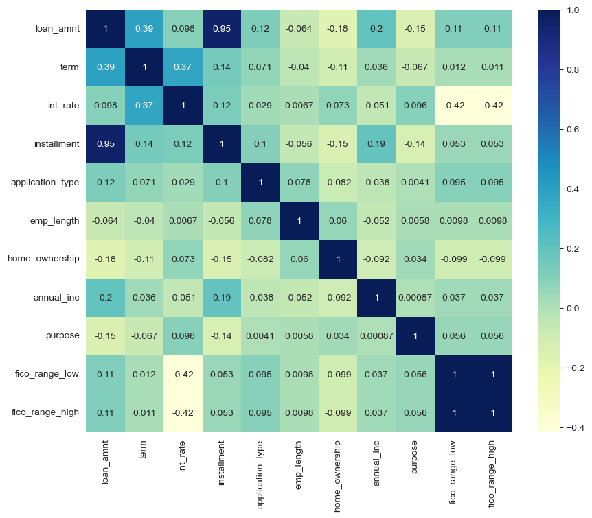

```python
plt.figure(figsize=(10,8))
sns.heatmap(df2_final.corr(), annot=True, cmap="YlGnBu")
```

#### Checking the coefficients

```python
cor = df2_final.corr()
cor.loc[:,:] = np.tril(cor, k=-1) # below main lower triangle of an array
cor = cor.stack()
cor[(cor > 0.1) | (cor < -0.1)]
```

```
term              loan_amnt         0.393766
int_rate          term              0.372626
installment       loan_amnt         0.945625
                  term              0.139222
                  int_rate          0.123951
application_type  loan_amnt         0.118437
                  installment       0.102258
home_ownership    loan_amnt        -0.179576
                  term             -0.108580
                  installment      -0.145435
annual_inc        loan_amnt         0.197246
                  installment       0.190270
purpose           loan_amnt        -0.150363
                  installment      -0.135561
fico_range_low    loan_amnt         0.110585
                  int_rate         -0.415989
fico_range_high   loan_amnt         0.110584
                  int_rate         -0.415997
                  fico_range_low    0.999997
dtype: float64
```

## **8.4 Spliting the data into test and train**

```python
X= df2_final[['term', 'int_rate', 'installment', 'application_type', 'emp_length', 'home_ownership', 'annual_inc', 'purpose', 'fico_range_low', 'fico_range_high']]
y= df2_final['loan_amnt']
X_train, X_test,y_train,y_test= train_test_split(X,y, test_size=0.2,random_state=42)
```

```python
X_train
```

|  | term | int_rate | installment | application_type | emp_length | home_ownership | annual_inc | purpose | fico_range_low | fico_range_high |
| --- | --- | --- | --- | --- | --- | --- | --- | --- | --- | --- |
| 1800887 | 0.0 | 14.33 | 446.40 | 0.0 | 5.0 | 1.0 | 83000.0 | 2.0 | 680.0 | 684.0 |
| 1130140 | 0.0 | 14.31 | 34.33 | 0.0 | 10.0 | 1.0 | 30000.0 | 10.0 | 720.0 | 724.0 |
| 459855 | 1.0 | 16.01 | 778.35 | 0.0 | 1.0 | 1.0 | 105000.0 | 2.0 | 710.0 | 714.0 |
| 283070 | 0.0 | 6.39 | 642.58 | 0.0 | 4.0 | 1.0 | 145000.0 | 1.0 | 695.0 | 699.0 |
| 1785392 | 0.0 | 12.99 | 404.27 | 0.0 | 2.0 | 5.0 | 55000.0 | 2.0 | 690.0 | 694.0 |
| ... | ... | ... | ... | ... | ... | ... | ... | ... | ... | ... |
| 732180 | 1.0 | 12.99 | 568.70 | 0.0 | 1.0 | 5.0 | 67000.0 | 1.0 | 675.0 | 679.0 |
| 110268 | 0.0 | 7.89 | 1095.00 | 0.0 | 0.0 | 5.0 | 150000.0 | 1.0 | 720.0 | 724.0 |
| 1692743 | 1.0 | 11.49 | 527.71 | 0.0 | 1.0 | 5.0 | 90000.0 | 2.0 | 730.0 | 734.0 |
| 2229084 | 1.0 | 15.99 | 364.70 | 0.0 | 1.0 | 1.0 | 48000.0 | 2.0 | 715.0 | 719.0 |
| 2219110 | 0.0 | 11.49 | 553.92 | 0.0 | 9.0 | 5.0 | 112000.0 | 2.0 | 675.0 | 679.0 |

1808560 rows × 10 columns

```python
y_train
```

```
1800887    13000.0
1130140     1000.0
459855     32000.0
283070     21000.0
1785392    12000.0
            ...
732180     25000.0
110268     35000.0
1692743    24000.0
2229084    15000.0
2219110    16800.0
Name: loan_amnt, Length: 1808560, dtype: float64
```

## **8.5 Standardizing numerical data**

```python
mod_num_cols= ['int_rate', 'installment', 'annual_inc', 'fico_range_low', 'fico_range_high']
ss= StandardScaler()
X_train[mod_num_cols]= ss.fit_transform(X_train[mod_num_cols])
X_test[mod_num_cols]= ss.transform(X_test[mod_num_cols])
X_train
```

|  | term | int_rate | installment | application_type | emp_length | home_ownership | annual_inc | purpose | fico_range_low | fico_range_high |
| --- | --- | --- | --- | --- | --- | --- | --- | --- | --- | --- |
| 1800887 | 0.0 | 0.255814 | 0.002094 | 0.0 | 5.0 | 1.0 | 0.041501 | 2.0 | -0.563046 | -0.563027 |
| 1130140 | 0.0 | 0.251675 | -1.540097 | 0.0 | 10.0 | 1.0 | -0.399323 | 10.0 | 0.648830 | 0.648815 |
| 459855 | 1.0 | 0.603484 | 1.244432 | 0.0 | 1.0 | 1.0 | 0.224484 | 2.0 | 0.345861 | 0.345855 |
| 283070 | 0.0 | -1.387344 | 0.736307 | 0.0 | 4.0 | 1.0 | 0.557181 | 1.0 | -0.108593 | -0.108586 |
| 1785392 | 0.0 | -0.021495 | -0.155580 | 0.0 | 2.0 | 5.0 | -0.191387 | 2.0 | -0.260077 | -0.260066 |
| ... | ... | ... | ... | ... | ... | ... | ... | ... | ... | ... |
| 732180 | 1.0 | -0.021495 | 0.459807 | 0.0 | 1.0 | 5.0 | -0.091578 | 1.0 | -0.714531 | -0.714507 |
| 110268 | 0.0 | -1.076924 | 2.429510 | 0.0 | 0.0 | 5.0 | 0.598768 | 1.0 | 0.648830 | 0.648815 |
| 1692743 | 1.0 | -0.331915 | 0.306400 | 0.0 | 1.0 | 5.0 | 0.099723 | 2.0 | 0.951800 | 0.951776 |
| 2229084 | 1.0 | 0.599345 | -0.303672 | 0.0 | 1.0 | 1.0 | -0.249609 | 2.0 | 0.497346 | 0.497335 |
| 2219110 | 0.0 | -0.331915 | 0.404493 | 0.0 | 9.0 | 5.0 | 0.282706 | 2.0 | -0.714531 | -0.714507 |

1808560 rows × 10 columns

## **8.6 Linear Regression Model**

#### **Fitting The Model**

```python
lr.fit(X_train, y_train)
```

```
LinearRegression()
```

```python
print(lr.intercept_)
print(lr.coef_)
```

```
13129.437283064552
[ 6.40593985e+03 -1.22603625e+03  8.43452154e+03  2.50996009e+02
  2.93280909e-01 -6.61533700e+00  3.96623878e+01  2.82557459e+01
 -1.79658419e+04  1.79776136e+04]
```

```python
coeff_df2 = pd.DataFrame(lr.coef_, X.columns, columns=['Coefficient'])
coeff_df2
```

|  | Coefficient |
| --- | --- |
| term | 6405.939853 |
| int_rate | -1226.036253 |
| installment | 8434.521540 |
| application_type | 250.996009 |
| emp_length | 0.293281 |
| home_ownership | -6.615337 |
| annual_inc | 39.662388 |
| purpose | 28.255746 |
| fico_range_low | -17965.841861 |
| fico_range_high | 17977.613616 |

```python
y_pred_train = lr.predict(X_train)
```

#### **Plotting the actual Y vs predicted Y for train dataset**

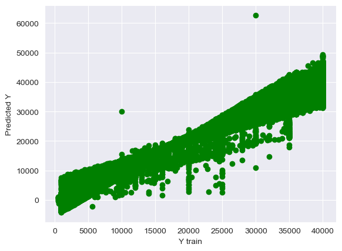

```python
plt.scatter(x = y_train, y = y_pred_train, color = "green")
plt.xlabel('Y train')
plt.ylabel('Predicted Y')
plt.show()
```

#### Looking at the metrics for the train data.

```python
print('MAE:', metrics.mean_absolute_error(y_train, y_pred_train))
print('MSE:', metrics.mean_squared_error(y_train, y_pred_train))
print('RMSE:', np.sqrt(metrics.mean_squared_error(y_train, y_pred_train))),
print('R-squared: ',explained_variance_score(y_train, y_pred_train))
```

```
MAE: 847.8638429833705
MSE: 1721971.227166671
RMSE: 1312.239012972359
R-squared:  0.9796212239435175
```

#### Making Predictions

```python
y_pred = lr.predict(X_test)
```

#### Comparing the actual output values for X_test with the predicted values.

```python
df3 = pd.DataFrame({'Actual': y_test, 'Predicted': y_pred})
df3
```

|  | Actual | Predicted |
| --- | --- | --- |
| 392949 | 32000.0 | 27905.665953 |
| 1273506 | 9600.0 | 9294.973589 |
| 324024 | 4000.0 | 4757.173943 |
| 2066630 | 6025.0 | 5857.825417 |
| 477199 | 25000.0 | 25911.088008 |
| ... | ... | ... |
| 1205942 | 35000.0 | 33326.458249 |
| 860827 | 35000.0 | 34779.460899 |
| 267134 | 24000.0 | 24419.624979 |
| 867240 | 10000.0 | 10510.119486 |
| 1123633 | 25000.0 | 25111.512795 |

452141 rows × 2 columns

#### **Evaluating The Algorithm**

#### Looking at the metrics for the test data.

```python
print('Mean Absolute Error:', metrics.mean_absolute_error(y_test, y_pred))
print('Mean Squared Error:', metrics.mean_squared_error(y_test, y_pred))
print('Root Mean Squared Error:', np.sqrt(metrics.mean_squared_error(y_test, y_pred)))
print('R-squared: ',explained_variance_score(y_test, y_pred))
```

```
Mean Absolute Error: 845.591377543284
Mean Squared Error: 1711299.4271931706
Root Mean Squared Error: 1308.1664371146244
R-squared:  0.9797008030847885
```

#### **Plotting Actual vs Predicted Values**

#### Plotting The Best Fit Line

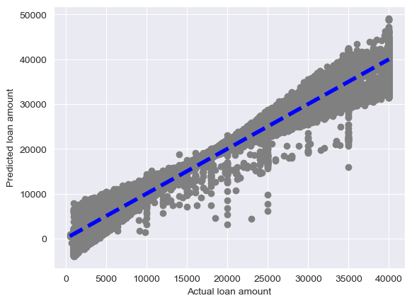

```python
fig, ax = plt.subplots()
ax.scatter(y_test, y_pred, color='grey')
ax.plot([y.min(), y.max()], [y.min(), y.max()], 'k--', lw=4, color='blue')
ax.set_xlabel('Actual loan amount')
ax.set_ylabel('Predicted loan amount')
plt.show()
```

#### **Checking the residuals**

#### Plotting a histogram of the residuals to check if it is normally distributed.

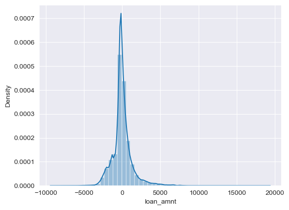

```python
sns.distplot((y_test-y_pred), bins = 50)
```

```python
prog_end = time.time()
```

```python
print("Total MODEL EXECUTION time: ", model_total_time/60 , "Minutes")
```

```
Total MODEL EXECUTION time:  5.956804740428924 Minutes
```

```python
total_prog_time = prog_end - prog_start

print("Total PROGRAM EXECUTION time: ", total_prog_time/60, "Minutes")
```

```
Total PROGRAM EXECUTION time:  9.879445731639862 Minutes
```